# R Notebook: Phylogenomic and contextual analysis of Yaws genomes from Lihir, Papua New Guinea

# Import environment and library dependencies

```r
R.Version()
```

```
$platform
[1] "x86_64-apple-darwin15.6.0"

$arch
[1] "x86_64"

$os
[1] "darwin15.6.0"

$system
[1] "x86_64, darwin15.6.0"

$status
[1] ""

$major
[1] "3"

$minor
[1] "6.0"

$year
[1] "2019"

$month
[1] "04"

$day
[1] "26"

$`svn rev`
[1] "76424"

$language
[1] "R"

$version.string
[1] "R version 3.6.0 (2019-04-26)"

$nickname
[1] "Planting of a Tree"
```

```r
library(ggplot2)
library(ggtree)
library(ggforce)
library(treeio)
library(plyr)
library(dplyr)
library(randomcoloR)
library(Cairo)
library(rPinecone)
library(lubridate)
library(seqinr)
library(phangorn)
library(pryr)
library(gridExtra)
library(readxl)
library(pegas)
library(phytools)
```

# Specify data to use

```r
# Full Maximum Likelihood Tree
tree.file <- "TPE_SamoaD_v1_bwa.74pc-genome-cov+.20190920.gubbins-WGS-aln.all.remasked.SNPs.aln.renamed.treefile"

# SNP scaled global tree
tree.SNPscale.file <- "TPE_SamoaD_v1_bwa.74pc-genome-cov+.20190920.gubbins-WGS-aln.all.remasked.SNPs.pyjar.joint.tre"


# Macrolide resistance data (from ARIBA, although also done by RFLP for those in this study - checked for consistency where possible)
macrolide.file <- "PNGL_Yaws_23s_ARIBA.summary.09-2019.renamed.csv"

# Full metadata spreadsheet
full.metadata.file <- "Supplementary Data_1__PNG-Lihir-Yaws_final_Paper_Metadata.xlsx"

# Transmission network epi data file for generating network plot
A2059G.net.file <- "PNG_Yaws_A2059G_Tx-network1__14102919.tsv"

# parsed VCF file with JG8 SNPs
TPP.vcf.file <- "TPE_SamoaD_v1_bwa.74pc-genome-cov+.20190920.gubbins-WGS-aln.all.remasked.JG8.vcf.tsv"


# fasta file with JG8 SNPs
JG8.fasta.file <- "TPE_SamoaD_v1_bwa.74pc-genome-cov+.20190920.gubbins-WGS-aln.all.remasked.JG8.SNPs.aln"


# Survey sample numbers and workflow
#sample.consort.raw.file <- "/Users/mb29/Papers/Yaws_Lihir_Genomic-Epi-23s_Paper_2019/Revision_03-2020/useful bits/rework_sample_consort+workflows/Revised_+_cleaned__Complete PNG PCRsummaries for typing R1-R8__27-03-2020.xlsx"
sample.consort.raw.file <- "redacted___Revised_+_cleaned__Complete PNG PCRsummaries for typing R1-R8__23-04-2020.xlsx"


# Sequencing performance metrics
seq.performance.file <- "Seq.performance.09-2019.tsv"


# Phylobayes with rooted guide tree
# consensus tree
phylobayes.contree.file <- "TPE_SamoaD_v1_bwa.74pc-genome-cov+.20190920.gubbins-WGS-aln.all.renamed.SNPs.root.phylobayes.1_sample.con.tre"
# Run file 1
phylobayes.run1.file <- "TPE_SamoaD_v1_bwa.74pc-genome-cov+.20190920.gubbins-WGS-aln.all.renamed.SNPs.root.phylobayes.1.treelist"
# Run file 2
phylobayes.run2.file <- "TPE_SamoaD_v1_bwa.74pc-genome-cov+.20190920.gubbins-WGS-aln.all.renamed.SNPs.root.phylobayes.2.treelist"
# subsample of all trees
phylobayes.sample.file <- "TPE_SamoaD_v1_bwa.74pc-genome-cov+.20190920.gubbins-WGS-aln.all.renamed.SNPs.root.phylobayes_sample.treelist"


# Deep Sequencing data (Supplementary Data 2)
deep.seq.alleles.file <- "Supplementary_Data_2__Deep-sequencing-23S-PileupResults_revised.xls"

# deep sequencing haplotype counts
bam2hap.all.file <- "operon1.+totals+q30bam2haplotype.tsv"


# Multiple sequence alignment for subsampling dataset to look at sites specific to R6-KOS-002 (Patient 1 pre-treatment sample) in context
index.failure.full.aln.file <- "TPE_74pc-genome-cov+_index-sample54pc.mfas.2020-04-22.renamed.vcf"
index.failure.full.sitelist.file <- "TPE_74pc-genome-cov+_index-sample54pc.mfas.2020-04-22.renamed.sitelist"

# Tree generated from subsetted multiple sequencealignment for R6-KOS-002
index.failure.tree.file <- "TPE_74pc-genome-cov+_index-sample54pc.index-seq-variable-sites.fas.treefile"
```

# Redo all sample workflow plots and analyses

```r
# Look at sample workflow plotting using raw data
sample.consort.raw <- read_excel(sample.consort.raw.file)

###

# How many passed initial MLST
sample.consort.raw.summary <- data.frame(sample.consort.raw %>%
                                           dplyr::group_by(Timepoint, Complete_MLST) %>%
                                           dplyr::summarize(Complete.MLST=n()))
colnames(sample.consort.raw.summary) <- c("Timepoint", "value","Complete MLST")

# How many were selected to represent the dataset
sample.consort.temp <- data.frame(sample.consort.raw %>% dplyr::group_by(Timepoint, Selected_to_represent_dataset) %>%
                                             dplyr::summarize(total=n()))
colnames(sample.consort.temp) <- c("Timepoint", "value","Selected Representatives")
sample.consort.raw.summary <- plyr::join(sample.consort.raw.summary,sample.consort.temp)
# How many passed qPCR filters at U Washington
sample.consort.temp <- data.frame(sample.consort.raw %>% dplyr::group_by(Timepoint, `qPCR_Ct<32_@UW`) %>%
                                    dplyr::summarize(total=n()))
colnames(sample.consort.temp) <- c("Timepoint", "value","qPCR UW")
sample.consort.raw.summary <- plyr::join(sample.consort.raw.summary,sample.consort.temp)
# How many were initially sent to WSI for sequencing
sample.consort.temp <- data.frame(sample.consort.raw %>% dplyr::group_by(Timepoint, sent_to_WSI) %>%
                                    dplyr::summarize(total=n()))
colnames(sample.consort.temp) <- c("Timepoint", "value","Sent to WSI")
sample.consort.raw.summary <- plyr::join(sample.consort.raw.summary,sample.consort.temp)
# How many passed qPCR filters at WSI
sample.consort.temp <- data.frame(sample.consort.raw %>% dplyr::group_by(Timepoint, `WSI_qPCR_Ct<32`) %>%
                                    dplyr::summarize(total=n()))
colnames(sample.consort.temp) <- c("Timepoint", "value","qPCR WSI")
sample.consort.raw.summary <- plyr::join(sample.consort.raw.summary,sample.consort.temp)
# How many were submitted for sequencing
sample.consort.temp <- data.frame(sample.consort.raw %>% dplyr::group_by(Timepoint, Sequenced) %>%
                                    dplyr::summarize(total=n()))
colnames(sample.consort.temp) <- c("Timepoint", "value","WGS Submitted")
sample.consort.raw.summary <- plyr::join(sample.consort.raw.summary,sample.consort.temp)
# How many were successfully sequenced
sample.consort.temp <- data.frame(sample.consort.raw %>% dplyr::group_by(Timepoint, Genome_Used_in_Tree) %>%
                                    dplyr::summarize(total=n()))
colnames(sample.consort.temp) <- c("Timepoint", "value","WGS Successful")
sample.consort.raw.summary <- plyr::join(sample.consort.raw.summary,sample.consort.temp)
# How many were submitted for Deep Sequencing
sample.consort.temp <- data.frame(sample.consort.raw %>% dplyr::group_by(Timepoint, Deep_Sequencing_Selected) %>%
                                    dplyr::summarize(total=n()))
colnames(sample.consort.temp) <- c("Timepoint", "value","Deep Sequencing Selected")
sample.consort.raw.summary <- plyr::join(sample.consort.raw.summary,sample.consort.temp)
# How many were successfully for Deep Sequenced
sample.consort.temp <- data.frame(sample.consort.raw %>% dplyr::group_by(Timepoint, Deep_Sequencing_Successful) %>%
                                    dplyr::summarize(total=n()))
colnames(sample.consort.temp) <- c("Timepoint", "value","Deep Sequencing Successful")
sample.consort.raw.summary <- plyr::join(sample.consort.raw.summary,sample.consort.temp)
# How many had resistance alleles
sample.consort.temp <- data.frame(sample.consort.raw %>% dplyr::group_by(Timepoint, Resistance_Allele) %>%
                                    dplyr::summarize(total=n()))
colnames(sample.consort.temp) <- c("Timepoint", "value","Resistance Allele")
sample.consort.raw.summary <- plyr::join(sample.consort.raw.summary,sample.consort.temp)
# Only keep 'yes' values
sample.consort.raw.summary.yes <- sample.consort.raw.summary[sample.consort.raw.summary$value=="yes",]
# replace NA with 0 counts
sample.consort.raw.summary.yes[is.na(sample.consort.raw.summary.yes)] <- 0


# Include totals
sample.consort.temp <- data.frame(sample.consort.raw %>% dplyr::group_by(Timepoint) %>% dplyr::summarize(total=n()))
colnames(sample.consort.temp) <- c("Timepoint", "TPE positive")
sample.consort.raw.summary.yes <- plyr::join(sample.consort.raw.summary.yes,sample.consort.temp)
sample.consort.raw.summary.yes
```

| Timepoint | value | Complete MLST | Selected Representatives | qPCR UW | Sent to WSI | qPCR WSI | WGS Submitted | WGS Successful | Deep Sequencing Selected | Deep Sequencing Successful | Resistance Allele | TPE positive |
| --- | --- | --- | --- | --- | --- | --- | --- | --- | --- | --- | --- | --- |
| 0 | yes | 17 | 17 | 0 | 0 | 0 | 0 | 0 | 0 | 0 | 0 | 22 |
| 6 | yes | 33 | 25 | 11 | 11 | 9 | 9 | 3 | 1 | 0 | 0 | 38 |
| 12 | yes | 16 | 5 | 4 | 4 | 4 | 4 | 2 | 5 | 5 | 0 | 20 |
| 18 | yes | 16 | 5 | 2 | 2 | 2 | 2 | 1 | 0 | 0 | 0 | 16 |
| 24 | yes | 10 | 3 | 3 | 3 | 3 | 3 | 2 | 4 | 4 | 0 | 13 |
| 30 | yes | 24 | 6 | 6 | 7 | 5 | 5 | 3 | 8 | 7 | 0 | 31 |
| 36 | yes | 30 | 7 | 4 | 6 | 5 | 6 | 4 | 10 | 10 | 2 | 41 |
| 42 | yes | 47 | 10 | 9 | 9 | 8 | 8 | 5 | 11 | 11 | 3 | 51 |

```r
# Make a first plot for the WGS workflow
#WGS.variables.plotting <- c("Timepoint", "TPE positive", "Complete MLST", "Selected Representatives", "qPCR UW", "Sent to WSI", "qPCR WSI", "WGS Submitted", "WGS Successful")
WGS.variables.plotting <- c("Timepoint", "TPE positive", "Complete MLST", "Selected Representatives", "qPCR WSI", "WGS Submitted", "WGS Successful")

Sample.workflow.WGS <- sample.consort.raw.summary.yes[,WGS.variables.plotting]
Sample.workflow.WGS.melt <- reshape2::melt(Sample.workflow.WGS, id.vars="Timepoint")


# Get totals
nrow(sample.consort.raw)
```

```
[1] 232
```

```r
sum(Sample.workflow.WGS$`TPE positive`)
```

```
[1] 232
```

```r
sum(Sample.workflow.WGS$`Complete MLST`)
```

```
[1] 193
```

```r
sum(Sample.workflow.WGS$`Selected Representatives`)
```

```
[1] 78
```

```r
sum(Sample.workflow.WGS$`qPCR UW`)
```

```
[1] 0
```

```r
sum(Sample.workflow.WGS$`Sent to WSI`)
```

```
[1] 0
```

```r
sum(Sample.workflow.WGS$`qPCR WSI`)
```

```
[1] 36
```

```r
sum(Sample.workflow.WGS$`WGS Submitted`)
```

```
[1] 37
```

```r
sum(Sample.workflow.WGS$`WGS Successful`)
```

```
[1] 20
```

```r
data.frame(sample.consort.raw[sample.consort.raw$Resistance_Allele=="yes",])
```

| Round | Timepoint | X548 | Tp0136 | Tp0326 | MLST | Imported | Complete_MLST | Selected_to_represent_dataset | qPCR_Ct.32_.UW | sent_to_WSI | WSI_qPCR_Ct | WSI_qPCR_Ct.32 | Sequenced | Genome_Used_in_Tree | Deep_Sequencing_Selected | Deep_Sequencing_Successful | Resistance_Allele |
| --- | --- | --- | --- | --- | --- | --- | --- | --- | --- | --- | --- | --- | --- | --- | --- | --- | --- |
| 7 | 36 | J | G | 8 | JG8 | - | yes | yes | no | yes | 31.717544555664062 | yes | yes | no | yes | yes | yes |
| 7 | 36 | J | G | 8 | JG8 | - | yes | yes | no | yes | 32.269203186035156 | no | yes | no | yes | yes | yes |
| 8 | 42 | J | G | 8 | JG8 | - | yes | yes | yes | yes | 26.725540161132812 | yes | yes | yes | yes | yes | yes |
| 8 | 42 | J | G | 8 | JG8 | - | yes | yes | yes | yes | 28.077192306518555 | yes | yes | yes | yes | yes | yes |
| 8 | 42 | J | G | 8 | JG8 | - | yes | yes | yes | yes | 24.906599044799805 | yes | yes | yes | yes | yes | yes |

```r
# Make plots

# Make a first plot for the WGS workflow
#WGS.variables.plotting <- c("Timepoint", "TPE positive", "Complete MLST", "Selected Representatives", "qPCR UW", "Sent to WSI", "qPCR WSI", "WGS Submitted", "WGS Successful")
WGS.variables.plotting <- c("Timepoint", "TPE positive", "Complete MLST", "Selected Representatives", "qPCR WSI", "WGS Submitted", "WGS Successful")

Sample.workflow.WGS <- sample.consort.raw.summary.yes[,WGS.variables.plotting]
Sample.workflow.WGS.melt <- reshape2::melt(Sample.workflow.WGS, id.vars="Timepoint")

Sample.workflow.WGS.cols <- data.frame(variable=WGS.variables.plotting[c(2:length(WGS.variables.plotting))],stringsAsFactors = F)
#Sample.workflow.WGS.cols$cols <-c("dodgerblue3","skyblue1","darkorange3","orange1","darkorchid3","orchid","forestgreen","seagreen2")
Sample.workflow.WGS.cols$cols <-c("dodgerblue3","skyblue1","darkorange3","orchid","forestgreen","seagreen2")


p.survey.stats.WGS <- ggplot(Sample.workflow.WGS.melt, aes(factor(Timepoint),value,fill=variable)) +
  geom_bar(stat="identity",position="dodge",width=0.8, color="black") +
  theme_bw() +
  theme(legend.position = "top") +
  labs(x="Survey Timepoint (months)", y="Sample Count", fill="Key") +
  scale_fill_manual(breaks= Sample.workflow.WGS.cols$variable, values=Sample.workflow.WGS.cols$cols) +
  NULL
#p.survey.stats.WGS


# Make a second plot for the deep sequencing  workflow
Deepseq.variables.plotting <- c("Timepoint", "TPE positive", "Deep Sequencing Selected", "Deep Sequencing Successful")
Sample.workflow.deepseq <- sample.consort.raw.summary.yes[,Deepseq.variables.plotting]
Sample.workflow.deepseq.melt <- reshape2::melt(Sample.workflow.deepseq, id.vars="Timepoint")

Sample.workflow.deepseq.cols <- data.frame(variable=Deepseq.variables.plotting[c(2:length(Deepseq.variables.plotting))],stringsAsFactors = F)
Sample.workflow.deepseq.cols$cols <- c("dodgerblue3","tomato3","salmon")

p.survey.stats.deepseq <- ggplot(Sample.workflow.deepseq.melt, aes(factor(Timepoint),value,fill=variable)) +
  geom_bar(stat="identity",position="dodge",width=0.3, color="black") +
  theme_bw() +
  theme(legend.position = "top") +
  labs(x="Survey Timepoint (months)", y="Sample Count", fill="Key") +
  scale_fill_manual(breaks= Sample.workflow.deepseq.cols$variable, values=Sample.workflow.deepseq.cols$cols) +
  NULL
#p.survey.stats.deepseq
```

# Now plot together

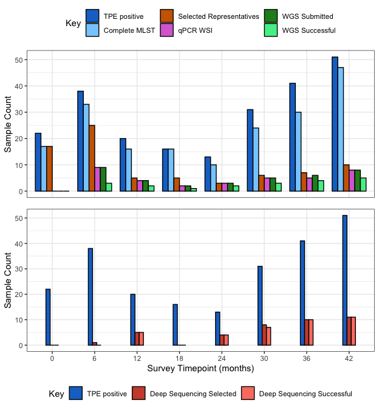

```r
# want to put them together, so remove x axis from top plot
x.theme.strip <- theme(axis.title.x = element_blank(), axis.text.x = element_blank(), axis.ticks.x= element_blank())

# plot together
gridExtra::grid.arrange(p.survey.stats.WGS + x.theme.strip,p.survey.stats.deepseq + theme(legend.position="bottom"), ncol=1)
```

```r
NA
NA
NA
```

Now look at distribiution of MLST types

```r
# Look at distribution of types
sample.MLST.summary <- data.frame(sample.consort.raw %>%
                                           dplyr::group_by(MLST,) %>%
                                           dplyr::summarize(Total=n()))
# Selected for representatives
sample.MLST.summary <- plyr::join(sample.MLST.summary,data.frame(sample.consort.raw[sample.consort.raw$Selected_to_represent_dataset=="yes",] %>%
                                                                  dplyr::group_by(MLST,) %>%
                                                                  dplyr::summarize(`Selected Representatives`=n())), by="MLST")
# passed UW qPCR
sample.MLST.summary <- plyr::join(sample.MLST.summary,data.frame(sample.consort.raw[(sample.consort.raw$`qPCR_Ct<32_@UW`=="yes"),] %>%
                                                                   dplyr::group_by(MLST) %>%
                                                                   dplyr::summarize(`qPCR UW`=n())), by="MLST")
# Sent to WSI
sample.MLST.summary <- plyr::join(sample.MLST.summary,data.frame(sample.consort.raw[(sample.consort.raw$sent_to_WSI=="yes"),] %>%
                                                                   dplyr::group_by(MLST) %>%
                                                                   dplyr::summarize(`Sent to WSI`=n())), by="MLST")
# passed WSI qPCR
sample.MLST.summary <- plyr::join(sample.MLST.summary,data.frame(sample.consort.raw[(sample.consort.raw$`WSI_qPCR_Ct<32`=="yes"),] %>%
                                                                   dplyr::group_by(MLST) %>%
                                                                   dplyr::summarize(WSI_qPCR=n())), by="MLST")
# Submitted to sequencing
sample.MLST.summary <- plyr::join(sample.MLST.summary,data.frame(sample.consort.raw[(sample.consort.raw$Sequenced=="yes"),] %>%
                                                                   dplyr::group_by(MLST) %>%
                                                                   dplyr::summarize(WGSsubmitted=n())), by="MLST")
# Sequencing Successful
sample.MLST.summary <- plyr::join(sample.MLST.summary,data.frame(sample.consort.raw[(sample.consort.raw$Genome_Used_in_Tree=="yes"),] %>%
                                                                   dplyr::group_by(MLST) %>%
                                                                   dplyr::summarize(WGSsuccessful=n())), by="MLST")

# Submitted for deep sequencing
sample.MLST.summary <- plyr::join(sample.MLST.summary,data.frame(sample.consort.raw[(sample.consort.raw$Deep_Sequencing_Selected=="yes"),] %>%
                                                                   dplyr::group_by(MLST) %>%
                                                                   dplyr::summarize(DeepSeqSelected=n())), by="MLST")
# Deep Sequencing Successful
sample.MLST.summary <- plyr::join(sample.MLST.summary,data.frame(sample.consort.raw[(sample.consort.raw$Deep_Sequencing_Successful=="yes"),] %>%
                                                                   dplyr::group_by(MLST) %>%
                                                                   dplyr::summarize(DeepSeqSuccessful=n())), by="MLST")


colnames(sample.MLST.summary) <- c("MLST", "TPE positive", "Selected Representatives", "qPCR UW", "Sent to WSI", "qPCR WSI", "WGS Submitted", "WGS Successful", "Deep Sequencing Selected", "Deep Sequencing Successful")

# Subset to include columns needed for plot
sample.MLST.summary <- sample.MLST.summary[,c("MLST", "TPE positive", "Selected Representatives", "qPCR WSI", "WGS Submitted", "WGS Successful", "Deep Sequencing Selected", "Deep Sequencing Successful")]

# replace NA with 0 counts
sample.MLST.summary[is.na(sample.MLST.summary)] <- 0
sample.MLST.summary[(sample.MLST.summary=="-")] <- "Untyped"
sample.MLST.summary.melt <- reshape2::melt(sample.MLST.summary, id.vars="MLST")


p.MLST.stage.proportions <- ggplot(sample.MLST.summary.melt , aes(variable,value,fill=factor(MLST))) +
  #geom_bar(stat="identity",position="stack",width=0.5, aes(color=NULL)) +
  geom_bar(stat="identity",position="dodge",width=.9, color="black") +
  #geom_bar(stat="identity",position="fill",width=0.5, aes(color=NULL)) +
  theme_bw() +
  theme(legend.position = "top", axis.text.x = element_text(angle = 45, hjust = 1)) +
  labs(x="Sample Stage", y="Sample Count", fill="Key") +
  facet_zoom(ylim = c(0, 50),show.area=T) +
  theme(legend.position="bottom")

#p.MLST.stage.proportions
```

Now plot all together

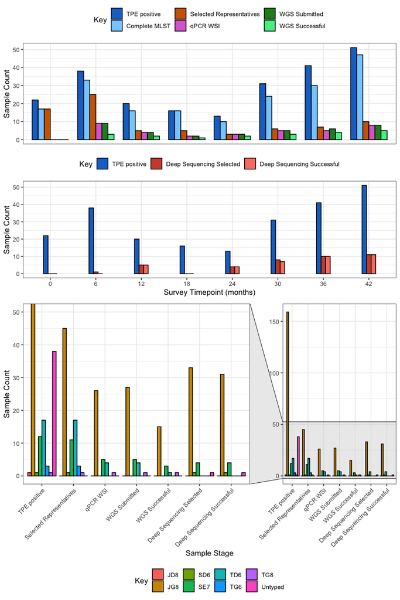

```r
# plot together
gridExtra::grid.arrange(p.survey.stats.WGS + x.theme.strip, p.survey.stats.deepseq, p.MLST.stage.proportions + theme(legend.position = "bottom"), ncol=1, heights=c(1,1,2))
```

```r
NA
NA
NA
```

# Do some analysis of qPCR vs sequencing performance

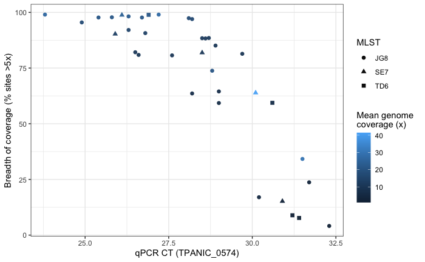

```r
#############
# Sample sequencing performance
seq.performance <- read.csv(seq.performance.file,sep="\t", comment.char = "",stringsAsFactors = F, header=T)

p.seq.performance <- ggplot(seq.performance[seq.performance$cov.5!="-",],aes(as.numeric(WSI_qPCR.Ct),as.numeric(cov.5),color=as.numeric(meancov.all),shape=Type)) +
  geom_point(size=2,alpha=0.95) +
  theme_bw() +
  labs(x="qPCR CT (TPANIC_0574)", y="Breadth of coverage (% sites >5x)", color="Mean genome \ncoverage (x)",shape="MLST") +
  NULL

p.seq.performance
```

# Import trees and do some basic processing

```r
# Read in ML tree
mytree.phylo <- phytools::midpoint.root(read.tree(tree.file))
mytree.phylo <- ape::drop.tip(mytree.phylo,"Treponema_pallidum_subsp_pertenue_str_SamoaD_v1.tpr_arp_0470_23Sa-masked",trim.internal=T)

# Read in SNP-scaled Tree
mytree.SNPscale.phylo <- phytools::midpoint.root(read.tree(tree.SNPscale.file))
#mytree.SNPscale.phylo <- ape::drop.tip(mytree.SNPscale.phylo,"Treponema_pallidum_subsp_pertenue_str_SamoaD_v1.tpr+arp+0470+23Sa-masked",trim.internal=T)


# Define shortened names to recode all samples (allows clean up of some sample IDs for consistency and ease of reading plots)
fix.tipnames <- data.frame(old.name=c("BosniaA", "Fribourg-Blanc", "Gambia-1", "Gambia-2", "NKNP-1", "CDC2", "Gauthier", "Ghana-051", "CDC_2575", "PNGL_R7-Kun2-001B", "PNGL_R7-Kun2-001", "PNGL_R8-LMC-012", "TaïNP-2", "Kampung_Dalan_K363", "Sei_Geringging_K403", "SamoaD", "PNGL_R3-Sal007", "TPP_CP0495", "TPP_CP0465", "TPP_CP0461", "TPP_CP0492", "PNGL_R2-SR001B", "PNGL_R3-Zu003", "PNGL_R7-Lan-005", "PNGL_R2-64919", "PNGL_R4-ZU-021", "PNGL_R6-HUR-007", "PNGL_C5-ZUE007", "PNGL_R6-LES004", "PNGL_R6-SAM1-001", "PNGL_C5-SAM001",
                                       "PNGL_R2-106190", "PNGL_R8-LMC-004", "PNGL_R8-MAZ-003", "PNGL_R7-Put1-002", "PNGL_R8-KOS-004", "PNGL_R8-KOS-007", "TPP_WP0022.5", "TPP_WP0022.7.liq", "TPP_WP0022.7.scab","PNGL_R6-KO5002","PNGL_R7-Kos-003","PNGL_R7-Kos-004"),
                           new.name=c("BosniaA", "Fribourg-Blanc", "Gambia-1", "Gambia-2", "NKNP-1", "CDC2", "Gauthier", "Ghana-051", "CDC_2575", "R7-KUN2-001B", "R7-KUN2-001", "R8-LMC-012", "TaïNP-2", "Kampung_Dalan_K363", "Sei_Geringging_K403", "SamoaD", "R3-SAL-007", "CP0495", "CP0465", "CP0461", "CP0492", "R2-SR-001B", "R3-ZU-003", "R7-LAN-005", "R2-64919", "R4-ZUE-021", "R6-HUR-007", "R5-ZUE-007", "R6-LES-004", "R6-SAM1-001", "R5-SAM-001", "R2-106190", "R8-LMC-004", "R8-MAZ-003", "R7-PUT1-002", "R8-KOS-004",
                                      "R8-KOS-007", "WP0022.5", "WP0022.7.liq", "WP0022.7.scab","R6-KOS-002","R7-KOS-003","R7-KOS-004"),
                           stringsAsFactors = F)


# Fix ML tree tipnames
mltree.tipnames <- data.frame(old.name=mytree.phylo$tip.label,stringsAsFactors = F)
mltree.tipnames <- plyr::join(mltree.tipnames,fix.tipnames, by="old.name")
mytree.phylo$tip.label <- mltree.tipnames$new.name

# Fix SNP scale tree tipnames
snpscale.tipnames <- data.frame(old.name=mytree.SNPscale.phylo$tip.label,stringsAsFactors = F)
snpscale.tipnames <- plyr::join(snpscale.tipnames,fix.tipnames, by="old.name")
mytree.SNPscale.phylo$tip.label <- snpscale.tipnames$new.name

# Bring in metadata and fix names
#mymeta <- read.csv(meta.file,sep="\t", stringsAsFactors = F, comment.char = "", header=T)

myfull.meta <-  readxl::read_excel(full.metadata.file)
mymeta <- myfull.meta

#colnames(mymeta) <- c("Sample","SampleShort","Year","Geo_location","seqdr","seqdrh")
mymeta$old.name <-  mymeta$Sample
mymeta <- plyr::join(mymeta,fix.tipnames, by="old.name")
mymeta <- mymeta[!is.na(mymeta$new.name),]
mymeta$Sample <- mymeta$new.name
```

# Basic ML tree

```r
# Do some processing on ML tree (e.g. nodes for bootstrapping)
mytree.phylo.data <- data.frame(ggtree(mytree.phylo)$data,stringsAsFactors=F)
mytree.phylo.data.nodes <- mytree.phylo.data[!mytree.phylo.data$isTip,]
mytree.phylo.data.nodes$label <- as.numeric(mytree.phylo.data.nodes$label)
```

```
NAs introduced by coercion
```

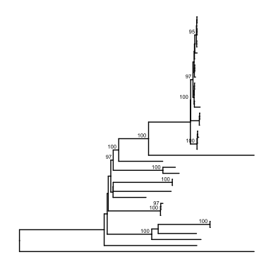

```r
mytree.phylo.data.nodes <- mytree.phylo.data.nodes[mytree.phylo.data.nodes$label >= 95,]

# now build tree
mytree.ggtree <- ggtree(mytree.phylo, ladderize = T) +
  geom_text(data=mytree.phylo.data.nodes, aes(label=label), size=2, hjust=1.25, vjust=-0.4)

mytree.ggtree
```

# Basic SNP scaled tree

```r
### Do some processing for SNP scaled tree
mymeta.country <- data.frame(Country=mymeta$Country, stringsAsFactors = T, row.names = mymeta$Sample)
distinctColorPalette(k=length(unique(mymeta.country$Country)))
```

```
 [1] "#BD49E6" "#7CE0D3" "#D96FC3" "#DD7665" "#87D68E" "#D5ADCD" "#A7E655" "#DCC367" "#80B4D8" "#8A7CD9"
[11] "#D6D7C3"
```

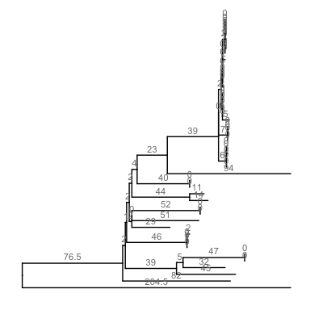

```r
# create a variable containing edge lengths and positions for plotting
edge <- data.frame(mytree.SNPscale.phylo$edge, edge_num=1:length(mytree.SNPscale.phylo$edge.length))
colnames(edge)=c("parent", "node", "edge_num")
edge$SNPs <- mytree.SNPscale.phylo$edge.length
edge <- data.frame(mytree.SNPscale.phylo$edge, edge_num=1:length(mytree.SNPscale.phylo$edge.length))
colnames(edge)=c("parent", "node", "edge_num")
edge$SNPs <- mytree.SNPscale.phylo$edge.length

# now build tree
mytree.SNPscale.ggtree <- ggtree(mytree.SNPscale.phylo, ladderize = T) %<+%
  edge + geom_text(aes(x=branch, label=SNPs, vjust=-.5),size=3,color="grey50")

mytree.SNPscale.ggtree
```

# Process and combine various metadata

```r
colnames(mymeta)[colnames(mymeta)=="Godornes_MLST"] <- "MLST"
colnames(mymeta)[colnames(mymeta)=="WGS_23S_A2059G"] <- "A2059G"

meta.plotting1.p <- mymeta[,c("Country","MLST","A2059G")]
row.names(meta.plotting1.p) <- mymeta$Sample
meta.plotting1.p[meta.plotting1.p$MLST=="-","MLST"] <- NA

meta.plotting1.p$Country <- gsub("^","1_",meta.plotting1.p$Country, perl=T)
meta.plotting1.p$MLST <- gsub("^","2_",meta.plotting1.p$MLST, perl=T)
meta.plotting1.p$A2059G <- gsub("^","3_",meta.plotting1.p$A2059G, perl=T)
meta.plotting1.p$A2059G <- gsub("no","No",gsub("yes","Yes",meta.plotting1.p$A2059G))
```

# Define plot colours

```r
# Define country colours
country.col <- c("#DA7B6E", "#D7AACB", "#D7DDD7", "#8286D1", "#D964C0", "#AC46E1", "#CEC990", "#DDD44F", "#7DDFB0", "#94E25C", "#83C9DB")

# Define MLST colours
#mlst.col <- c("#92D6D8", "#8E94D7", "#D9C2D1", "#AE48DF", "#DB6BC0", "#7FDFA3", "#D87C73", "#D4CB94", "#BFDE51")
mlst.col <- c("#92D6D8", "#8E94D7", "#D9C2D1", "#AE48DF",              "#7FDFA3", "#D87C73", "#D4CB94", "#BFDE51")

# Define A2059G colours
macrolide.col <- c("grey20","red")

tree.metacols <- data.frame(tag=(unique(as.character(unlist(meta.plotting1.p[,c("Country","MLST","A2059G")])))),stringsAsFactors=F)
tree.metacols <- data.frame(tag=sort(tree.metacols[!is.na(tree.metacols$tag),]),stringsAsFactors=F)

tree.metacols$col <- c(country.col,mlst.col,macrolide.col)
```

# Plot ML Tree with metadata

```r
#mytree.ggtree.combi <- mytree.ggtree %>%
#  gheatmap(meta.plotting1.p, colnames_position="top",font.size=3,width=0.5,offset=0.0025) +
#  geom_tiplab(size=2.5,align=T) + geom_treescale(fontsize=3,y=15,x=0.0005)  +
#  scale_fill_manual(breaks=tree.metacols$tag,values=tree.metacols$col,labels=gsub("\\_","\\ ",gsub("^[1-3]+\\_","",tree.metacols$tag, perl=T)))

mytree.ggtree.combi <- mytree.ggtree %>%
  gheatmap(meta.plotting1.p, colnames_position="top",font.size=3,width=0.5,offset=0.000125) +
  geom_tiplab(size=2.5,align=T) + geom_treescale(fontsize=3,y=15,x=0.00075)  +
  scale_fill_manual(breaks=tree.metacols$tag,values=tree.metacols$col,labels=gsub("\\_","\\ ",gsub("^[1-3]+\\_","",tree.metacols$tag, perl=T)))
```

```
Duplicated aesthetics after name standardisation: sizeScale for 'fill' is already present. Adding another scale for 'fill', which will replace the existing scale.
```

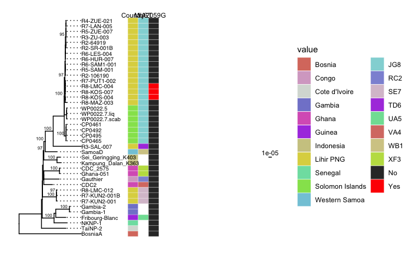

```r
mytree.ggtree.combi
```

```r
NA
NA
```

# Process JG8 tree and phylo

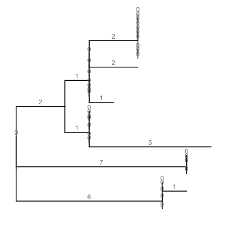

```r
# Generate all possible subtrees
mytree.SNPscale.subtrees <- ape::subtrees(mytree.SNPscale.phylo)

# Extract specific JG8 subtree
#current.subtree.id <- 16
current.subtree.id <- 17
current.subtree <- mytree.SNPscale.subtrees[[current.subtree.id]]

# specify edge lengths (SNPs) for subtree
subtree.edge <- data.frame(current.subtree$edge, edge_num=1:length(current.subtree$edge.length))
colnames(subtree.edge) <- c("parent","node","edge_num")
subtree.edge$SNPs <- current.subtree$edge.length

# merge metadata with tree data
mytree.SNPscale.ggtree2 <- ggtree(mytree.SNPscale.phylo)
mytree.SNPscale.data2 <- mytree.SNPscale.ggtree2$data
#subtree.meta <- mymeta[(mymeta$MLST=="JG8" & mymeta$Genome_Used_in_Tree=="yes"),c("Sample","Village","A2059G","MDA_Round")]

subtree.meta <- mymeta[(mymeta$MLST=="JG8" & mymeta$Genome_Used_in_Tree=="yes"),c("Sample","Village","A2059G","MDA_Round","Travel_History")]

mytree.SNPscale.data.meta <- merge(mytree.SNPscale.data2, subtree.meta, by.x="label",by.y="Sample")

# Define resistant strains to colour tip labels
resistant.strains <- mytree.SNPscale.data.meta[mytree.SNPscale.data.meta$A2059G=="yes","label"]
current.subtree <- groupOTU(current.subtree, resistant.strains)

# Plot tree and add edge labels (SNPs)
current.subtree.snps.ggtree <- ggtree(current.subtree) %<+%
  subtree.edge +
  geom_text(aes(x=branch, label=SNPs, vjust=-.5),size=3,color="grey50")

current.subtree.snps.ggtree
```

# Run rPinecone clustering and prepare clusters and variable labels for tree

```r
####
# Run rPinecone on JG8 subtree
#JG8.pinecone.output <- rPinecone::pinecone(current.subtree,5,1)
JG8.pinecone.output <- rPinecone::pinecone(current.subtree,4,1)
```

```
    23 taxa found from phylogenetic tree

Node_1  will be investigated.

Node_2  will be investigated.
Threhold met - Sub-lineage Number assigned:  1
CP0495  skipped as this is a leaf.
CP0492  skipped as this is a leaf.
CP0461  skipped as this is a leaf.
CP0465  skipped as this is a leaf.

Node_3  will be investigated.

Node_4  will be investigated.
Threhold met - Sub-lineage Number assigned:  2
R6-LES-004  skipped as this is a leaf.
R6-HUR-007  skipped as this is a leaf.
R5-SAM-001  skipped as this is a leaf.
R6-SAM1-001  skipped as this is a leaf.
R2-106190  skipped as this is a leaf.

Node_5  will be investigated.
R2-SR-001B  skipped as this is a leaf.
R2-64919  skipped as this is a leaf.
R3-ZU-003  skipped as this is a leaf.
R5-ZUE-007  skipped as this is a leaf.
R7-LAN-005  skipped as this is a leaf.
R4-ZUE-021  skipped as this is a leaf.

Node_6  will be investigated.
Internal sub-lineage detected - Sub-lineage number assigned:  3
R8-LMC-004  skipped as this is a leaf.
R7-PUT1-002  skipped as this is a leaf.
R8-KOS-007  skipped as this is a leaf.
R8-MAZ-003  skipped as this is a leaf.
R8-KOS-004  skipped as this is a leaf.

Node_7  will be investigated.
Threhold met - Sub-lineage Number assigned:  4
WP0022.7.scab  skipped as this is a leaf.
WP0022.7.liq  skipped as this is a leaf.
WP0022.5  skipped as this is a leaf.

Number of Isolates on tree:  23
Number of Sub-lineages identified:  4
Number of Major Sublineages identified:  1
Number of Singletons remain:  1
Major Sub-Lineages  1 is composed of  4  Sub-lineages &  23  isolates.
```

```r
JG8.pinecone.output.tab <- data.frame(JG8.pinecone.output$table,stringsAsFactors = F)

# Convert 'Singleton's into sublineages for cleanness
sublineage.relabelling <- data.frame(Sub.lineage=sort(unique(JG8.pinecone.output.tab$Sub.lineage)),stringsAsFactors = F)
sublineage.relabelling$newSublineages <- paste0("JG8.c",c(1:nrow(sublineage.relabelling)))


JG8.pinecone.output.tab <- plyr::join(JG8.pinecone.output.tab, sublineage.relabelling, by="Sub.lineage")

mytree.SNPscale.data.meta.JG8 <- mytree.SNPscale.data.meta
colnames(mytree.SNPscale.data.meta.JG8)[1] <- "Taxa"
JG8.pinecone.output.tab <- plyr::join(JG8.pinecone.output.tab,mytree.SNPscale.data.meta.JG8, by="Taxa")
```

# Define colours and plot JG8 subtree

```r
# Setup label names
JG8.pinecone.output.tab2 <- JG8.pinecone.output.tab
#JG8.pinecone.output.tab2[is.na(JG8.pinecone.output.tab2),]
JG8.pinecone.output.tab2[JG8.pinecone.output.tab2$Village=="-","Village"] <- NA
JG8.pinecone.output.tab2[JG8.pinecone.output.tab2$MDA_Round=="-","MDA_Round"] <- NA

JG8.pinecone.output.tab2$newSublineages <- gsub("^","1_",JG8.pinecone.output.tab2$newSublineages)
JG8.pinecone.output.tab2$Village <- gsub("^","2_",JG8.pinecone.output.tab2$Village)
JG8.pinecone.output.tab2$MDA_Round <- gsub("^","3_",JG8.pinecone.output.tab2$MDA_Round)
JG8.pinecone.output.tab2$MDA_Round <- gsub("Round","R",JG8.pinecone.output.tab2$MDA_Round)
JG8.pinecone.output.tab2$MDA_Round.numeric <- as.numeric(gsub("3_R","",JG8.pinecone.output.tab2$MDA_Round))

palette.blue <- colorRampPalette(c('black','#762a83','#af8dc3','#e7d4e8','#d9f0d3','#7fbf7b','#1b7837'))

JG8.pinecone.output.tab2[is.na(JG8.pinecone.output.tab2$MDA_Round.numeric),"MDA_Round.numeric"] <- 0
JG8.pinecone.output.tab2$MDA_Round.col <- palette.blue(9)[as.numeric(cut(JG8.pinecone.output.tab2$MDA_Round.numeric,breaks=9))]
JG8.pinecone.output.tab2[JG8.pinecone.output.tab2$MDA_Round.numeric==0,"MDA_Round.col"] <- NA

# Colors for Sublineage
sublin.cols <- data.frame(newSublineages=sort(unique(JG8.pinecone.output.tab2$newSublineages)),stringsAsFactors = F)
sublin.cols$Sublineage.col <- c("#A1E35F", "#DCC980","#DB7B7C","#8BDFBB", "#B898D4")
JG8.pinecone.output.tab2 <- plyr::join(JG8.pinecone.output.tab2,sublin.cols, by="newSublineages")

# Colors for Village
village.cols <- data.frame(Village=c("2_Kosmayun", "2_Mazuz", "2_Samo","2_Zuen","2_Hurtol", "2_Landolam", "2_Lissel", "2_Putput","2_Missing"),stringsAsFactors = F)
village.cols$village.col <- c('#b2182b','#d6604d','#f4a582','#fddbc7','#d1e5f0','#92c5de','#4393c3','#2166ac',"white")
JG8.pinecone.output.tab2 <- plyr::join(JG8.pinecone.output.tab2,village.cols, by="Village")


# Colors for Travel History
travel.cols <- data.frame(Travel_History=sort(unique(JG8.pinecone.output.tab2$Travel_History)),stringsAsFactors = F)
travel.cols[travel.cols$Travel_History=="-",] <- NA
travel.cols$Travel.col <- c("white","lightgoldenrodyellow","orange3")
travel.cols <- travel.cols[!is.na(travel.cols$Travel_History),]
travel.cols$Travel_History <- gsub("^","4\\_",travel.cols$Travel_History, perl=T)

JG8.pinecone.output.tab2$Travel_History <- gsub("^","4\\_",JG8.pinecone.output.tab2$Travel_History, perl=T)
JG8.pinecone.output.tab2[JG8.pinecone.output.tab2$Travel_History=="4_-","Travel_History"] <- NA
JG8.pinecone.output.tab2 <- plyr::join(JG8.pinecone.output.tab2,travel.cols, by="Travel_History")


# Combine colours and taxa into single dataframe
combine.cols.df <- data.frame(variable=c((JG8.pinecone.output.tab2$newSublineages),((JG8.pinecone.output.tab2$Village)),(JG8.pinecone.output.tab2$MDA_Round),(JG8.pinecone.output.tab2$Travel_History)),stringsAsFactors = F)

combine.cols.df5 <- data.frame(tag=(unique(as.character(unlist(JG8.pinecone.output.tab2[,c("newSublineages","Village","MDA_Round","Travel_History")])))),stringsAsFactors=F)
combine.cols.df5$col <- unique(as.character(unlist(JG8.pinecone.output.tab2[,c("Sublineage.col","village.col","MDA_Round.col","Travel.col")])))

combine.cols.df5 <- combine.cols.df5[combine.cols.df5$tag!="2_Missing",]
combine.cols.df5.sort <- combine.cols.df5[order(combine.cols.df5$tag),]

# Subset data for plotting
pinecone.plotting3 <- data.frame(row.names=JG8.pinecone.output.tab2$Taxa,Sub.lineage=JG8.pinecone.output.tab2$newSublineages,Village=JG8.pinecone.output.tab2$Village,MDA.round=JG8.pinecone.output.tab2$MDA_Round, Travel_History=JG8.pinecone.output.tab2$Travel_History, stringsAsFactors = F)


pinecone.plotting3[(pinecone.plotting3$Village=="2_Missing" & !is.na(pinecone.plotting3$Village=="2_Missing")) ,"Village"] <- NA
```

# Plot Tree

```r
# Plot Tree
current.subtree.snps.ggtree.hm <- current.subtree.snps.ggtree %>%
  gheatmap(pinecone.plotting3, colnames_position="top",font.size=3,offset=5,width=0.25) +
  geom_tiplab(aes(color=group),size=2.5,align=T,offset=1) +
  scale_fill_manual(breaks=factor(combine.cols.df5.sort$tag,levels=sort(combine.cols.df5.sort$tag)), values=combine.cols.df5.sort$col,labels=gsub("^.+\\_","",combine.cols.df5.sort$tag,perl=T)) +
  scale_color_manual(values = c("black","red")) +
  geom_treescale(y=22,x=3,fontsize=3, width=1) +
  NULL
```

```
Duplicated aesthetics after name standardisation: sizeScale for 'fill' is already present. Adding another scale for 'fill', which will replace the existing scale.
```

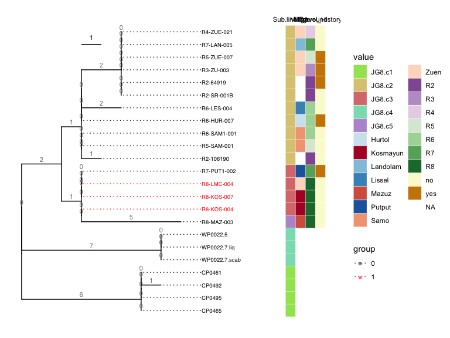

```r
# Additional cleaning of Legend and labels performed in inkscape

current.subtree.snps.ggtree.hm
```

```r
NA
NA
```

# Plot basic transmission network for A2059G cluster

```r
# Attempt to build figure for A2059G resistance network

# Read in data
A2059G.net <- read.table(A2059G.net.file,header = T, sep="\t",stringsAsFactors = F)

# Fix dates
A2059G.net$Date <- as.Date(A2059G.net$Date,"%d/%m/%Y")
A2059G.net$Episode.start <- A2059G.net$Date - lubridate::weeks(A2059G.net$Weeks.Duration)

#Do some relabelling
A2059G.net$A2059G <- ifelse(A2059G.net$A2059G=="yes","Resistant","Sensitive")
A2059G.net$Patient.revised <- factor(gsub("\\_","\\ ",A2059G.net$Patient.revised),levels=c("Patient 5", "Patient 7", "Patient 6", "Patient 4", "Patient 3", "Patient 2", "Patient 1"))

# Make plot
plot.A2059G.net <- ggplot(A2059G.net,aes(Date, Patient.revised)) +
  # Set up initial plot (need to specify points here to get scales right)
  geom_point(aes(shape=Genome2,color=A2059G.mix),size=9) +
  scale_color_manual(values=c("lightcoral","red","black")) +
  # Specify village colours for background
  #geom_rect( aes(xmin=as.Date("01/09/2015","%d/%m/%Y"), xmax=as.Date("30/12/2016","%d/%m/%Y"), ymin=1.525, ymax=7.58), fill="#b2182b", alpha=0.04,inherit.aes=F) +
  geom_rect( aes(xmin=as.Date("01/09/2015","%d/%m/%Y"), xmax=as.Date("30/12/2016","%d/%m/%Y"), ymin=1.525, ymax=8.58), fill="#b2182b", alpha=0.04,inherit.aes=F) +
    geom_rect( aes(xmin=as.Date("01/09/2015","%d/%m/%Y"), xmax=as.Date("30/12/2016","%d/%m/%Y"), ymin=0.42, ymax=1.475), fill="#fddbc7", alpha=0.04,inherit.aes=F) +
  # Plot episode duration line
  geom_rect(aes(xmin=Date, xmax=Episode.start, ymin=Patient.revised, ymax=Patient.revised,color=A2059G.mix),inherit.aes = F,size=3) +
  # Plot outer point colour
  geom_point(aes(shape=Genome2,color=A2059G.mix),size=9) +
  # Plot inner point colour
  geom_point(aes(shape=Genome2),size=6.5,color="white") +
  # Plot episode duration inner line
  geom_rect(aes(xmin=Date, xmax=Episode.start, ymin=Patient.revised, ymax=Patient.revised),inherit.aes = F,size=1,color="white") +
  theme_bw() +
  # Set scales and axes limits
  scale_x_date(date_labels = "%m/%Y",date_minor_breaks = "1 month",expand = expand_scale(mult = c(0.0, 0.0))) +
  coord_cartesian(xlim=c(as.Date("01/10/2015","%d/%m/%Y"),as.Date("15/12/2016","%d/%m/%Y"))) +
  # Add Sample names below each sampling point
  geom_text(data=A2059G.net,aes(Date, Patient.revised,label=gsub("PNGL\\_","",Sample)),size=2,
            nudge_y=-0.33) +
  # Clean up axis labels
  labs(x="Sample Date", y="Patient")
```

```
`expand_scale()` is deprecated; use `expansion()` instead.
```

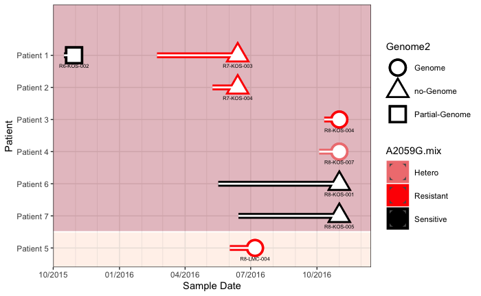

```r
# Final cleaning of legend, plus addition of epidemiological links drawn in inkscape.

plot.A2059G.net
```

# Import SNPs vs JG8 tree

```r
# SNP positional plot
TPP.vcf <- read.table(TPP.vcf.file,stringsAsFactors = F, header=T, sep="\t",comment.char = "")

# Define seqnames (R import messes them up)
seqnames <- c("TPP_WP0022.7.liq", "TPP_CP0495", "TPP_CP0492", "TPP_WP0022.7.scab", "TPP_CP0461", "TPP_WP0022.5", "TPP_CP0465", "PNGL_R2-SR001B", "PNGL_R8-LMC-004", "PNGL_C5-SAM001", "PNGL_R6-SAM1-001", "PNGL_R2-106190", "PNGL_R8-MAZ-003", "PNGL_R8-KOS-004", "PNGL_R3-Zu003", "PNGL_R2-64919", "PNGL_R8-KOS-007", "PNGL_R7-Put1-002", "PNGL_C5-ZUE007", "PNGL_R7-Lan-005", "PNGL_R6-HUR-007", "PNGL_R4-ZU-021", "PNGL_R6-LES004")


vcf.header <- c("CHROM","POS","ID","REF","ALT","QUAL","FILTER","INFO","FORMAT")
vcf.seqnames <- c(vcf.header,seqnames)
colnames(TPP.vcf) <- vcf.seqnames

# Cleanup sites to only include confirmed SNPs (not missing/n/*)
TPP.vcf$ALT1 <- sapply(1:nrow(TPP.vcf), function (x) strsplit(TPP.vcf$ALT[x],split=",")[[1]][1])
TPP.vcf$ALT2 <- sapply(1:nrow(TPP.vcf), function (x) strsplit(TPP.vcf$ALT[x],split=",")[[1]][2])

TPP.vcf$ALT1 <- gsub("\\*","n",TPP.vcf$ALT1)
TPP.vcf$ALT2 <- gsub("\\*","n",TPP.vcf$ALT2)
# get rid of NA by making 'n' - note these are NOT true 'n', so need to comment out if want 'n' for all sites in analysis
TPP.vcf$ALT2[is.na(TPP.vcf$ALT2)] <- "n"


TPP.vcf.cleanup <- TPP.vcf[,c("POS","ALT1","ALT2",seqnames)]
TPP.vcf.cleanup <- data.frame(POS=TPP.vcf$POS,ALT1=TPP.vcf$ALT1,ALT2=TPP.vcf$ALT2,
                              t(sapply(1:nrow(TPP.vcf.cleanup), function(x) sapply(seqnames,function(y) ifelse(TPP.vcf.cleanup[x,y]==1 & TPP.vcf.cleanup[x,"ALT1"]=="n",0,TPP.vcf.cleanup[x,y])))),stringsAsFactors = F)
colnames(TPP.vcf.cleanup) <- c("POS","ALT1","ALT2",seqnames)

TPP.vcf.cleanup <- data.frame(POS=TPP.vcf$POS,ALT1=TPP.vcf$ALT1,ALT2=TPP.vcf$ALT2,
                              t(sapply(1:nrow(TPP.vcf.cleanup), function(x) sapply(seqnames,function(y) ifelse(TPP.vcf.cleanup[x,y]==2 & TPP.vcf.cleanup[x,"ALT2"]=="n",0,TPP.vcf.cleanup[x,y])))),stringsAsFactors = F)
colnames(TPP.vcf.cleanup ) <- c("POS","ALT1","ALT2",seqnames)
TPP.vcf.cleanup <- data.frame(POS=TPP.vcf$POS,ALT1=TPP.vcf$ALT1,ALT2=TPP.vcf$ALT2,
                              t(sapply(1:nrow(TPP.vcf.cleanup), function(x) sapply(seqnames,function(y) ifelse(TPP.vcf.cleanup[x,y]==2 & TPP.vcf.cleanup[x,"ALT2"]!="n",1,TPP.vcf.cleanup[x,y])))),stringsAsFactors = F)
colnames(TPP.vcf.cleanup ) <- c("POS","ALT1","ALT2",seqnames)

# Convert sequence alignment file into a dataframe (gene.aln)
gene.aln <- TPP.vcf.cleanup[,c("POS",seqnames)]
rownames(gene.aln) <- gene.aln$POS
colnames(gene.aln) <- c("POS",seqnames)

# Only keep samples of interest for JG8 study
gene.aln.full <- gene.aln
gene.aln.study <- gene.aln[,colnames(gene.aln) %in% fix.tipnames[fix.tipnames$new.name %in% current.subtree$tip.label,"old.name"]]
gene.aln <- gene.aln.study
gene.aln$position <- rownames(gene.aln)


# List sites
sort(as.numeric(gene.aln$position))
```

```
 [1]  129509  150624  156223  156225  168058  185500  337334  396366  493442  591804  621704  651890  658079
[14]  708102  747030  791789  810450  815224  825116  905209  964363  975917  975920  994294 1030850 1089315
[27] 1133160 1135842
```

```r
vcf.seqnames
```

```
 [1] "CHROM"             "POS"               "ID"                "REF"               "ALT"
 [6] "QUAL"              "FILTER"            "INFO"              "FORMAT"            "TPP_WP0022.7.liq"
[11] "TPP_CP0495"        "TPP_CP0492"        "TPP_WP0022.7.scab" "TPP_CP0461"        "TPP_WP0022.5"
[16] "TPP_CP0465"        "PNGL_R2-SR001B"    "PNGL_R8-LMC-004"   "PNGL_C5-SAM001"    "PNGL_R6-SAM1-001"
[21] "PNGL_R2-106190"    "PNGL_R8-MAZ-003"   "PNGL_R8-KOS-004"   "PNGL_R3-Zu003"     "PNGL_R2-64919"
[26] "PNGL_R8-KOS-007"   "PNGL_R7-Put1-002"  "PNGL_C5-ZUE007"    "PNGL_R7-Lan-005"   "PNGL_R6-HUR-007"
[31] "PNGL_R4-ZU-021"    "PNGL_R6-LES004"
```

```r
###
# Aggregate SNPs into sliding windows for larger genomes
windowsize <- 1000       # specify size of window
genomelength <- 1139430
nwindows <- genomelength/windowsize

# Create a copy of binary matrix and define bins
gene.aln2 <- gene.aln
row.names(gene.aln2) <- gene.aln2$position
gene.aln2$window <- ((trunc(as.numeric(rownames(gene.aln2)) / windowsize,0))*windowsize) # create binning variables and re-label to nearest bin

JG8.seqnames <- fix.tipnames[fix.tipnames$new.name %in% current.subtree$tip.label,"old.name"]

gene.aln.windowed <- unique(gene.aln2$window)
snps.windowed.counts <- unique(gene.aln2$window)

gene.aln3 <- gene.aln2

# Loop through all sequences, and if there is a SNP (1) within the window, make it a 1
for (seq in JG8.seqnames){
  snps.window <- aggregate(as.numeric(gene.aln2[,seq]), list(gene.aln2$window), max) # aggregate depth based on bin and calculate mean
  snps.window[,2] <- as.character(snps.window[,2])
  gene.aln.windowed <- cbind(gene.aln.windowed,snps.window[,2])

  snps.window.count <- aggregate(as.numeric(gene.aln3[,seq]), list(gene.aln3$window), sum) # aggregate depth based on bin and calculate mean
  snps.window.count[,2] <- as.character(snps.window.count[,2])
  snps.windowed.counts <- cbind(snps.windowed.counts,snps.window.count[,2])
}
gene.aln.windowed <- data.frame(gene.aln.windowed,stringsAsFactors = F)
colnames(gene.aln.windowed) <- c("window",JG8.seqnames)

snps.windowed.counts <- data.frame(snps.windowed.counts,stringsAsFactors = F)
colnames(snps.windowed.counts) <- c("window",JG8.seqnames)

# Generate the plot of SNP presence/absence
gene.aln.windowed.melt <- reshape2::melt(gene.aln.windowed, id.vars="window")
colnames(gene.aln.windowed.melt) <- c("Position","Sequence","Variant")
gene.aln.windowed.melt$Position <- as.numeric(gene.aln.windowed.melt$Position)
```

# Plot JG8 subtree with SNPs

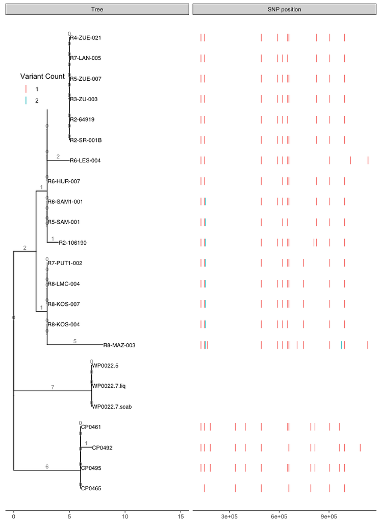

```r
### ggtree
# Just presence/absence in window
gene.aln.windowed.melt2 <- gene.aln.windowed.melt
# Or with count per window
gene.aln.windowed.melt2  <- reshape2::melt(snps.windowed.counts, id.vars="window")
colnames(gene.aln.windowed.melt2) <- c("Position","Sequence","Variant")
#
gene.aln.windowed.melt2$old.name <- gene.aln.windowed.melt2$Sequence
gene.aln.windowed.melt2 <- plyr::join(gene.aln.windowed.melt2,fix.tipnames,by="old.name")
gene.aln.windowed.melt2 <- gene.aln.windowed.melt2[,c("new.name","Position","Variant")]
colnames(gene.aln.windowed.melt2) <- c("Sample","Position","Variant Count")
gene.aln.windowed.melt2 <- gene.aln.windowed.melt2[gene.aln.windowed.melt2$Variant!=0,]

# Generate Tree
p.JG8.tree.SNPpos <- current.subtree.snps.ggtree + xlim_tree(15) +
  geom_facet(panel = "SNP position", data = gene.aln.windowed.melt2, geom = geom_point,
               mapping=aes(x = as.numeric(Position), color=`Variant Count`), shape = '|',size=4) +
  theme_tree2(legend.position=c(0.10, .85)) +
  geom_tiplab(size=3) +
  NULL

p.JG8.tree.SNPpos
```

This plot nicely shows the genomic position of SNPs, but because the sequencing was low coverage, we find some of these sites are missing due to insufficient coverage (they have been blanked to ‘N’). To show the allelic variation, we import the MSA and plot this aswell.

# Incorporate specific variants into plot

```r
# Add MSA plot to show whether each SNP is supported or 'N'
JG8.fasta <- read.fasta(file=JG8.fasta.file , seqtype="DNA", as.string=T,set.attributes=F)

# Capture and relabel the sequence names and make them pretty
JG8.fasta.seqnames <- data.frame(old.name=names(JG8.fasta),stringsAsFactors = F)
JG8.fasta.seqnames <- plyr::join(JG8.fasta.seqnames,fix.tipnames, by="old.name")

# Convert sequence alignment file into a dataframe (gene.aln)
JG8.gene.aln <- data.frame((as.matrix.alignment(seqinr::as.alignment(nb=length(JG8.fasta.seqnames$new.name),nam=NULL,seq=JG8.fasta,com=NULL))), stringsAsFactors = F)
JG8.gene.aln$Sample <- JG8.fasta.seqnames$new.name
JG8.gene.aln <- JG8.gene.aln[,c(ncol(JG8.gene.aln),1:(ncol(JG8.gene.aln)-1))]
JG8.gene.aln.melt <- reshape2::melt(JG8.gene.aln,id.vars="Sample")
colnames(JG8.gene.aln.melt) <- c("Sample","SNP","Allele")
JG8.gene.aln.melt$Allele[JG8.gene.aln.melt$Allele=='-'] <- 'n'
JG8.gene.aln.melt$Allele <- factor(JG8.gene.aln.melt$Allele, levels=c("a","c","g","t","n"))

# Make a new plot showing the alleles
p.JG8.tree.SNPpos.vars <- p.JG8.tree.SNPpos +
  geom_facet(panel = "Variant Sites", data = JG8.gene.aln.melt, geom = geom_tile,
             mapping=aes(x = as.numeric(SNP), fill=Allele),color="white") +
  scale_fill_manual(values=c("indianred2","lemonchiffon","lightgreen","skyblue1","gray80")) +
  NULL
```

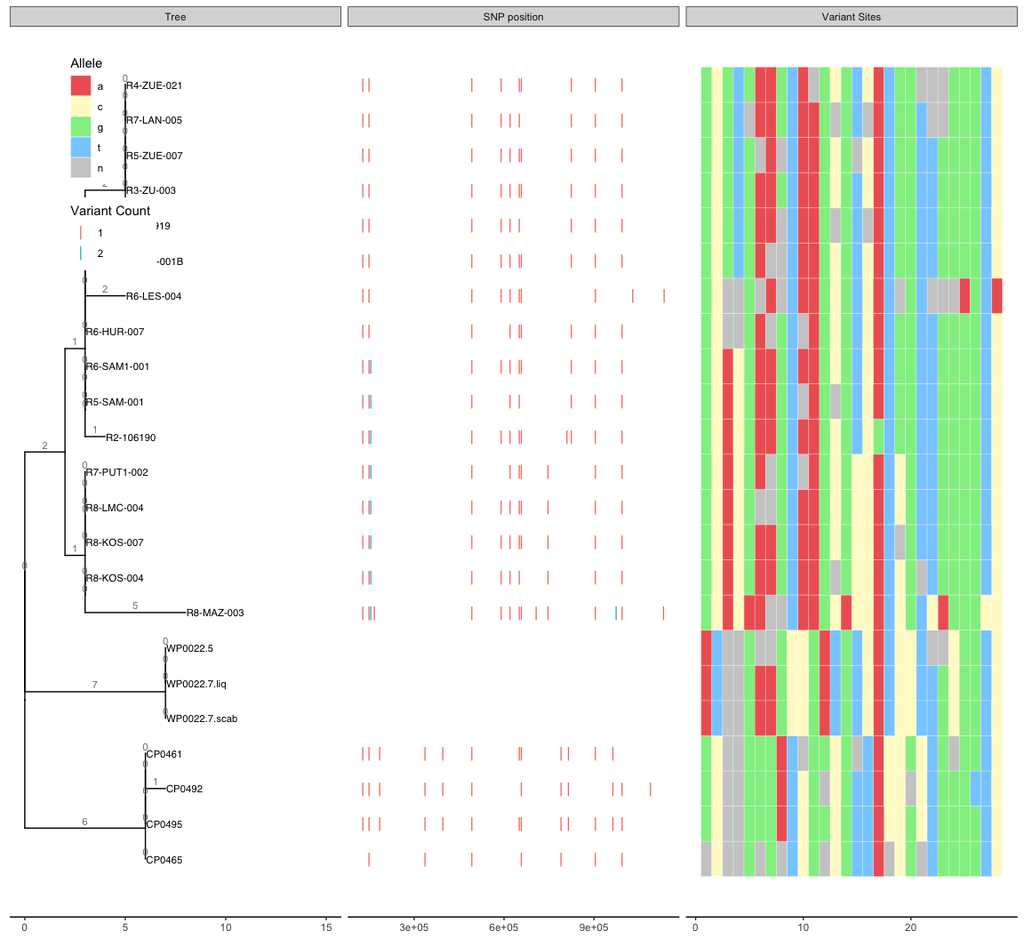

```r
p.JG8.tree.SNPpos.vars
```

```r
NA
NA
```

# Look at Phylobayes outputs to confirm tree topology

```r
#library(phangorn)

phylobayes.contree <- read.tree(phylobayes.contree.file)
phylobayes.run1 <- read.tree(phylobayes.run1.file)
phylobayes.run2 <- read.tree(phylobayes.run2.file)
phylobayes.sample <- read.tree(phylobayes.sample.file)


# Combine trees, removing first 10% (burnin)
treecount <- length(phylobayes.run1)
treecount
```

```
[1] 14200
```

```r
burnin <- (treecount/10) +1
phylobayes.combined.runs <- c(phylobayes.run1[burnin:treecount],phylobayes.run2[burnin:treecount])
length(phylobayes.combined.runs)
```

```
[1] 25560
```

```r
length(phylobayes.sample)
```

```
[1] 1410
```

```r
# Build consensus network from combined trees, including any edges present in at least 1% of trees
phylobayes.combined.consensusnet <- phangorn::consensusNet(phylobayes.combined.runs,prob=0.01)
# Identify edges present in the consensus network that are absent from the consensus tree
phylobayes.confidences <- phangorn::addConfidences(phylobayes.combined.consensusnet,phylobayes.contree,scaler=0.01)
split.col <- rep("black",length(phylobayes.confidences$splits))
split.col[!phangorn::matchSplits(phangorn::as.splits(phylobayes.confidences), phangorn::as.splits(phylobayes.contree))] <- "red"

# Fix tipnames (to be consistent with elsewhere in the analysis)
phylobayes.tiplabs <- data.frame(old.name=phylobayes.combined.consensusnet$tip.label)
phylobayes.tiplabs <- plyr::join(phylobayes.tiplabs,fix.tipnames,by="old.name")
phylobayes.tiplabs$tip.col <- c( "aquamarine3", "aquamarine3", "hotpink1", "hotpink1", "hotpink1", "hotpink1", "darkorchid3","orange1", "orange1", "orange1", "orange1", "orange1", "orange1", "orange1", "orange1", "orange1", "orange1", "orange1","springgreen4", "springgreen4", "springgreen4", "springgreen4","black", "black", "black", "black", "black", "black", "black", "black", "black", "black", "black","black","black","black","black","black","black","aquamarine3")
phylobayes.combined.consensusnet$tip.label <- phylobayes.tiplabs$new.name
phylobayes.confidences$tip.label <- phylobayes.tiplabs$new.name
```

Plot network - this is not scaled by branch length, and simply shows topology. From this, the sub-lineage clustering described in our ML phylogenies is confirmed.

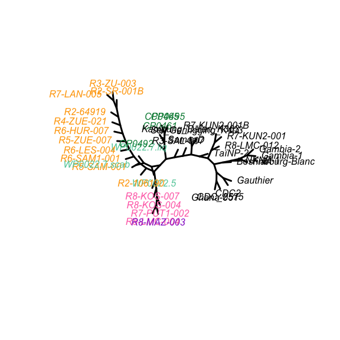

```r
# Plot phylobayes network. Any unsupported edges not in tree would be coloured red
plot(phylobayes.confidences,"2D",show.edge.label=F, split.color=split.col,nomatch="red",tip.color=phylobayes.tiplabs$tip.col)
```

### Further look at phylobayes in a densiTree

It isn’t reasonable to plot 25,560 trees here, so we will use a subsampled dataset of 1410 trees

```r
# Compare against ML tree (reread in)
mytree.phylo2 <- phytools::midpoint.root(read.tree(tree.file))

# define some tip colours to match our sub-lineages
densi.tiplabs.cols <- rev(c("black", "black", "black", "black", "black", "black", "black", "black", "black", "black", "black", "black", "black", "black", "black", "black", "black", "springgreen4", "springgreen4", "springgreen4", "springgreen4", "hotpink1", "hotpink1", "hotpink1", "darkorchid3", "hotpink1", "orange1", "orange1", "orange1", "orange1", "orange1", "orange1", "orange1", "orange1", "orange1", "orange1", "orange1", "aquamarine3", "aquamarine3", "aquamarine3"))
```

Although difficult to see due to scale, the sublineage clustering is maintained here.

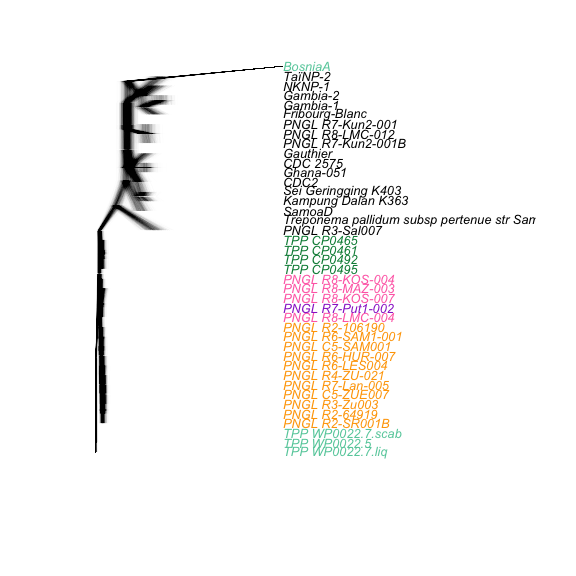

```r
# Now plot the densiTree
phangorn::densiTree(phylobayes.sample,"cladogram",alpha=(1/length(phylobayes.sample))*10,
                    scaleX=T,consensus=mytree.phylo2,scale.bar=F,tip.color = densi.tiplabs.cols)
```

# Put these two base graphics objects into a single plot

```r
# put these plots into objects we can plot as panels

p1.pryr %<a-% {plot(phylobayes.confidences,"2D",show.edge.label=F, split.color=split.col,nomatch="red",tip.color=phylobayes.tiplabs$tip.col)}

p2.pryr %<a-% {phangorn::densiTree(phylobayes.sample,"cladogram",alpha=(1/length(phylobayes.sample))*10,
                      scaleX=T,consensus=mytree.phylo2,scale.bar=F,tip.color = densi.tiplabs.cols)}

split.screen(c(1, 2))
```

```
[1] 1 2
```

```r
screen(1)
```

```r
p1.pryr
screen(2)
```

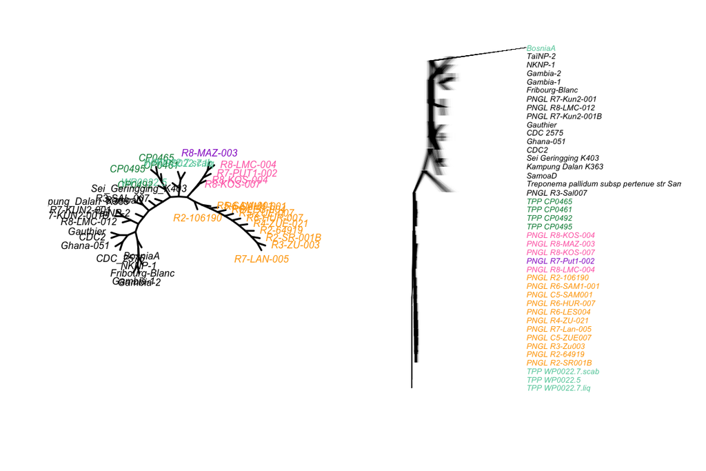

```r
p2.pryr
close.screen(all=TRUE)
```

```r
NA
NA
NA
NA
```

Beast tree analysis

```r
#Beast.tree.file <- "TPE_SamoaD_v1_bwa.74pc-genome-cov+.20190920.gubbins-WGS-aln.all.renamed.+dates.no-invariant+N.StrictConstant_combined.consensus.tree"

Beast.tree.file <- "TPE_SamoaD_v1_bwa.74pc-genome-cov+.20190920.gubbins-WGS-aln.all.renamed.+dates.no-invariant+N.StrictConstant_combined.consensus.renamed.tree"
```

```r
# Bring in beast tree and extract tree data into dataframe
yaws.beast.tree <- read.beast(Beast.tree.file)
yaws.beast.tree.data <- fortify(yaws.beast.tree)

yaws.beast.tree@phylo$tip.label
```

```
 [1] "BosniaA"             "CDC2"                "CDC_2575"            "Fribourg-Blanc"
 [5] "Gambia-1"            "Gambia-2"            "Gauthier"            "Ghana-051"
 [9] "Kampung_Dalan_K363"  "NKNP-1"              "PNGL_C5-SAM001"      "PNGL_C5-ZUE007"
[13] "PNGL_R2-106190"      "PNGL_R2-64919"       "PNGL_R2-SR001B"      "PNGL_R3-Sal007"
[17] "PNGL_R3-Zu003"       "PNGL_R4-ZU-021"      "PNGL_R6-HUR-007"     "PNGL_R6-LES004"
[21] "PNGL_R6-SAM1-001"    "PNGL_R7-Kun2-001"    "PNGL_R7-Kun2-001"    "PNGL_R7-Lan-005"
[25] "PNGL_R7-Put1-002"    "PNGL_R8-KOS-004"     "PNGL_R8-KOS-007"     "PNGL_R8-LMC-004"
[29] "PNGL_R8-LMC-012"     "PNGL_R8-MAZ-003"     "SamoaD"              "Sei_Geringging_K403"
[33] "TPP_CP0461"          "TPP_CP0465"          "TPP_CP0492"          "TPP_CP0495"
[37] "TPP_WP0022.5"        "TPP_WP0022.7.liq"    "TPP_WP0022.7.scab"   "TaïNP-2"
```

```r
# Fix ML tree tipnames
beast.tipnames <- data.frame(old.name=yaws.beast.tree@phylo$tip.label,stringsAsFactors = F)
beast.tipnames <- plyr::join(beast.tipnames,fix.tipnames, by="old.name")
yaws.beast.tree@phylo$tip.label <- beast.tipnames$new.name
yaws.beast.tree@phylo$tip.label
```

```
 [1] "BosniaA"             "CDC2"                "CDC_2575"            "Fribourg-Blanc"
 [5] "Gambia-1"            "Gambia-2"            "Gauthier"            "Ghana-051"
 [9] "Kampung_Dalan_K363"  "NKNP-1"              "R5-SAM-001"          "R5-ZUE-007"
[13] "R2-106190"           "R2-64919"            "R2-SR-001B"          "R3-SAL-007"
[17] "R3-ZU-003"           "R4-ZUE-021"          "R6-HUR-007"          "R6-LES-004"
[21] "R6-SAM1-001"         "R7-KUN2-001"         "R7-KUN2-001"         "R7-LAN-005"
[25] "R7-PUT1-002"         "R8-KOS-004"          "R8-KOS-007"          "R8-LMC-004"
[29] "R8-LMC-012"          "R8-MAZ-003"          "SamoaD"              "Sei_Geringging_K403"
[33] "CP0461"              "CP0465"              "CP0492"              "CP0495"
[37] "WP0022.5"            "WP0022.7.liq"        "WP0022.7.scab"       "TaïNP-2"
```

```r
# Plot minimally annotated BEAST Tree (no tip labels or colours)
yaws.beast.tree.plot <- ggtree(yaws.beast.tree,mrsd="2016-08-13",ladderize = T) +
  theme_tree2() +
# Add date lines for easy interpretation
  scale_x_continuous(breaks=c(1500,1600,1700,1800, 1900, 1990, 2000,2010, 2015), minor_breaks=seq(2000, 2016, 2)) +
  theme(panel.grid.major   = element_line(color="grey50", size=.2),
        panel.grid.minor   = element_line(color="grey85", size=.2),
        panel.grid.major.y = element_blank(),
        panel.grid.minor.y = element_blank()) #+ xlim_tree(2090)
# Add posterior support as node points
yaws.beast.tree.plot <- yaws.beast.tree.plot + geom_point2(aes(subset=(!isTip & as.numeric(posterior)>0.8)),color="gray60",size=3,alpha=0.5) +
  geom_point2(aes(subset=(!isTip & as.numeric(posterior)>0.91)),color="gray40",size=3,alpha=0.5) +
  geom_point2(aes(subset=(!isTip & as.numeric(posterior)>=0.96)),color="black",size=3,alpha=0.5)
```

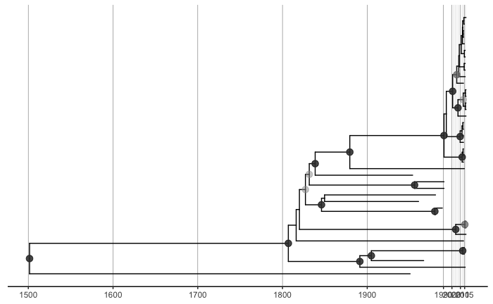

```r
yaws.beast.tree.plot
```

```r
yaws.beast.tree.subtree <- tree_subset(yaws.beast.tree, node=52,levels_back=0)

# apply group to allow colouring of taxa by resistance
yaws.beast.tree.subtree <- groupOTU(yaws.beast.tree.subtree, resistant.strains)

# flip the hpd intervals
yaws.beast.tree.subtree@data$height_0.95_HPD <- lapply(1:length(yaws.beast.tree.subtree@data$height_0.95_HPD), function (x) rev(yaws.beast.tree.subtree@data$height_0.95_HPD[[x]]))


yaws.beast.tree.subtree.plot <- ggtree(yaws.beast.tree.subtree,mrsd="2016-08-13",ladderize = T) +
  theme_tree2() +
# Add date lines for easy interpretation
  scale_x_continuous(breaks=c(1990,1995,2000,2005,2010,2015), minor_breaks=seq(2005, 2017, 1)) +
  theme(panel.grid.major   = element_line(color="grey50", size=.2),
        panel.grid.minor   = element_line(color="grey85", size=.2),
        panel.grid.major.y = element_blank(),
        panel.grid.minor.y = element_blank()) #+ xlim_tree(2090)
# Add posterior support as node points
yaws.beast.tree.subtree.plot <- yaws.beast.tree.subtree.plot + geom_point2(aes(subset=(!isTip & as.numeric(posterior)>0.8)),color="gray60",size=3,alpha=0.5) +
  geom_point2(aes(subset=(!isTip & as.numeric(posterior)>0.91)),color="gray40",size=3,alpha=0.5) +
  geom_point2(aes(subset=(!isTip & as.numeric(posterior)>=0.96)),color="black",size=3,alpha=0.5) +
  #geom_range(range='height_0.95_HPD',color='red', alpha=.25, size=2,branch.length="height_median") +
  NULL
```

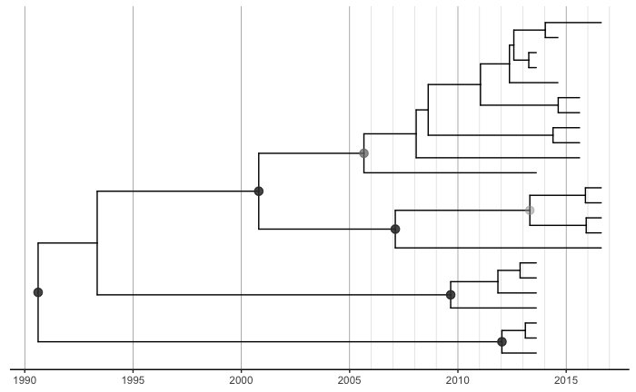

```r
yaws.beast.tree.subtree.plot #%<+% #edge + geom_text(aes(x=branch, label=SNPs, vjust=-.5),size=3,color="grey50")
```

```r
yaws.beast.tree.subtree.plot.meta <- yaws.beast.tree.subtree.plot %>% gheatmap(pinecone.plotting3, colnames_position="top",font.size=3,offset=5,width=0.25) +
  geom_tiplab(aes(color=group),size=2.5,align=T,offset=1) +
  scale_fill_manual(breaks=factor(combine.cols.df5.sort$tag,levels=sort(combine.cols.df5.sort$tag)),values=combine.cols.df5.sort$col,labels=gsub("^.+\\_","",combine.cols.df5.sort$tag,perl=T)) +
  scale_color_manual(values = c("black","red")) +
  NULL
```

```
Duplicated aesthetics after name standardisation: sizeScale for 'fill' is already present. Adding another scale for 'fill', which will replace the existing scale.
```

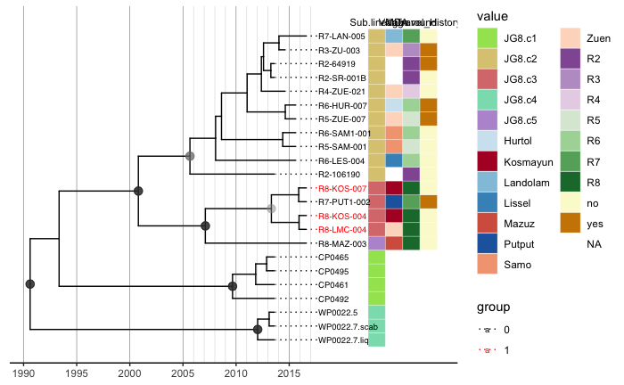

```r
yaws.beast.tree.subtree.plot.meta
```

Ok, so BEAST is splitting the JG8.c3 genomes into two clusters. This is odd, because there are no SNPs between them. Let’s just confirm this in the alignment used for BEAST

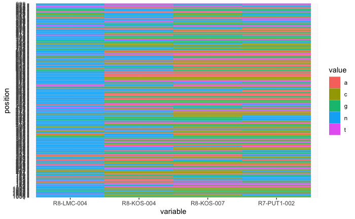

```r
beast.msa.file <- "/Users/mb29/Treponema/PNG_Lihir_Yaws_2018/Analysis/Phylo/gubbins_global_2019-09-20_masked/beast/TPE_SamoaD_v1_bwa.74pc-genome-cov+.20190920.gubbins-WGS-aln.all.renamed.+dates.no-invariant+N.fasta"

beast.msa <- seqinr::read.fasta(file=beast.msa.file , seqtype="DNA", as.string=T,set.attributes=F)

# Capture and relabel the sequence names and make them pretty
beast.msa.seqnames <- data.frame(old.name=gsub("\\|.+$","",names(beast.msa),perl=T),stringsAsFactors = F)
beast.msa.seqnames <- plyr::join(beast.msa.seqnames,fix.tipnames, by="old.name")

# Convert sequence alignment file into a dataframe (gene.aln)
beast.msa.aln <- data.frame((as.matrix.alignment(seqinr::as.alignment(nb=length(beast.msa.seqnames$new.name),nam=NULL,seq=beast.msa,com=NULL))), stringsAsFactors = F)

beast.msa.aln$Sample <- beast.msa.seqnames$new.name
beast.msa.aln <- beast.msa.aln[,c(ncol(beast.msa.aln),1:(ncol(beast.msa.aln)-1))]
colnames(beast.msa.aln) <- gsub("X","",colnames(beast.msa.aln))


# Pull out the JG8.c3 samples

beast.msa.aln.JG8.c3 <- beast.msa.aln[beast.msa.aln$Sample %in% c("R8-LMC-004","R8-KOS-004","R8-KOS-007","R7-PUT1-002"),]
beast.msa.aln.JG8.c3.melt <- reshape2::melt(beast.msa.aln.JG8.c3, id.vars="Sample")

#ggplot(beast.msa.aln.JG8.c3.melt, aes(variable, Sample, fill=value)) + geom_tile()

beast.msa.aln.JG8.c3.trans <- data.frame(t(beast.msa.aln.JG8.c3),stringsAsFactors = F)
colnames(beast.msa.aln.JG8.c3.trans) <- beast.msa.aln.JG8.c3.trans[1,]
beast.msa.aln.JG8.c3.trans <- beast.msa.aln.JG8.c3.trans[c(2:nrow(beast.msa.aln.JG8.c3.trans)),]

beast.msa.aln.JG8.c3.trans$changes <- sapply(1:nrow(beast.msa.aln.JG8.c3.trans), function(x) ifelse(length(unique(as.character(beast.msa.aln.JG8.c3.trans[x,])))==1,"fixed","variant"))

beast.msa.aln.JG8.c3.trans$position <- rownames(beast.msa.aln.JG8.c3.trans)

beast.msa.aln.JG8.c3.variants <- beast.msa.aln.JG8.c3.trans[beast.msa.aln.JG8.c3.trans$changes=="variant",]
beast.msa.aln.JG8.c3.variants.melt <- reshape2::melt(beast.msa.aln.JG8.c3.trans[beast.msa.aln.JG8.c3.trans$changes=="variant",c("position","R8-LMC-004","R8-KOS-004","R8-KOS-007","R7-PUT1-002")], id.vars="position")

ggplot(beast.msa.aln.JG8.c3.variants.melt, aes(variable, position,  fill=value)) +
  geom_tile()
```

```r
NA
NA
```

```r
# seems like most are 'n' - which of those changes are SNPs?
beast.msa.aln.JG8.c3.variants$SNP.changes <- sapply(1:nrow(beast.msa.aln.JG8.c3.variants), function(x) ifelse(sum(nchar(unique(gsub("n","",as.character(beast.msa.aln.JG8.c3.trans[x,c("R8-LMC-004","R8-KOS-004","R8-KOS-007","R7-PUT1-002")])))))<=1,"n","SNP"))

beast.msa.aln.JG8.c3.variants[beast.msa.aln.JG8.c3.variants$SNP.changes=="SNP",]
```

| R8-KOS-004 | R8-LMC-004 | R7-PUT1-002 | R8-KOS-007 | changes | position | SNP.changes |
| --- | --- | --- | --- | --- | --- | --- |

```r
NA
```

Ok, so these are indeed identical apart from the ‘n’ sites

# Plot deep sequencing allele data

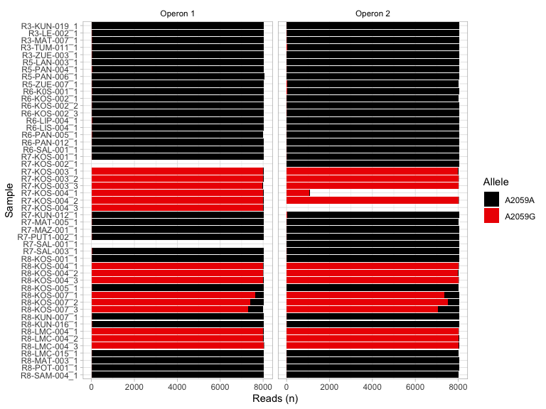

```r
#
deep.seq.alleles <- read_excel(deep.seq.alleles.file)
deep.seq.alleles.filt <- deep.seq.alleles[(deep.seq.alleles$GoodCoverage=="Yes" & deep.seq.alleles$ControlSample=="No" & deep.seq.alleles$E.Coli_equivalent_position==2059),]

deep.seq.alleles.filt$A2059A <- deep.seq.alleles.filt$Coverage - deep.seq.alleles.filt$G_Total
deep.seq.alleles.filt$A2059G <- deep.seq.alleles.filt$G_Total


deep.seq.alleles.filt.melt <- reshape2::melt(deep.seq.alleles.filt[,c("SampleID2","A2059A","A2059G","Operon","Replicate")],
                                             id.vars=c("SampleID2", "Operon", "Replicate"))

deep.seq.alleles.filt.melt$SampleID3 <- paste0(deep.seq.alleles.filt.melt$SampleID2,"_",deep.seq.alleles.filt.melt$Replicate)
deep.seq.alleles.filt.melt$Operon <- gsub("^","Operon\\ ",deep.seq.alleles.filt.melt$Operon, perl=T)
deep.seq.alleles.filt.melt$SampleID3 <- factor(deep.seq.alleles.filt.melt$SampleID3, levels=rev(sort(unique(deep.seq.alleles.filt.melt$SampleID3))))

plot.deepseq.alleles <- ggplot(deep.seq.alleles.filt.melt, aes(SampleID3, value, fill=variable)) +
  geom_bar(stat="identity", position="stack") +
  theme_light() + theme(strip.background =element_rect(fill="white"),strip.text = element_text(colour = 'black')) +
  scale_fill_manual(values=c("black","red2")) +
  labs(x="Sample", y="Reads (n)", fill="Allele") +
  facet_grid(.~c(Operon)) +
  coord_flip() +
  NULL

plot.deepseq.alleles
```

Get some additional stats on alleles

```r
deep.seq.passing <- data.frame(deep.seq.alleles[(deep.seq.alleles$E.Coli_equivalent_position==2059 & deep.seq.alleles$ControlSample=="No"),],stringsAsFactors = F)

deep.seq.passing$SampleID3 <- paste0(deep.seq.passing$SampleID2,"_",deep.seq.passing$Replicate)


# unique samples (excluding controls)
length(unique(deep.seq.passing$SampleID2))
```

```
[1] 39
```

```r
# unique samples (including replicates)
length(unique(deep.seq.passing$SampleID3))
```

```
[1] 53
```

```r
# Samples with passing Operon 1
length(deep.seq.passing[(deep.seq.passing$Operon==1 & deep.seq.passing$GoodCoverage=="Yes"),"SampleID3"])
```

```
[1] 47
```

```r
# Samples with passing Operon 2
length(deep.seq.passing[(deep.seq.passing$Operon==2 & deep.seq.passing$GoodCoverage=="Yes"),"SampleID3"])
```

```
[1] 48
```

```r
#deep.seq.passing.summary <- deep.seq.passing[deep.seq.passing$GoodCoverage=="Yes",] %>%
deep.seq.passing.summary <- deep.seq.passing[,] %>%
  dplyr::group_by(SampleID2, Operon, GoodCoverage, NGSResistant) %>%
  dplyr::summarise(sample.count=n()) %>%
  tidyr::spread(Operon, GoodCoverage)
deep.seq.passing.summary <- data.frame(deep.seq.passing.summary,stringsAsFactors = F)
colnames(deep.seq.passing.summary) <- c("Sample", "NGSResistant", "sample.count", "Operon_1_coverage_OK","Operon_2_coverage_OK")
deep.seq.passing.summary <- deep.seq.passing.summary[,c(1,2,4,5,3)]

deep.seq.passing.summary
```

| Sample | NGSResistant | Operon_1_coverage_OK | Operon_2_coverage_OK | sample.count |
| --- | --- | --- | --- | --- |
| R2-KOM-2001A | No | No | NA | 2 |
| R2-KOM-2001A | No | NA | No | 3 |
| R2-KOM-2001A | Yes | No | NA | 3 |
| R3-KUN-019 | No | Yes | Yes | 1 |
| R3-LE-002 | No | Yes | Yes | 1 |
| R3-MAT-007 | No | Yes | Yes | 1 |
| R3-TUM-011 | No | Yes | Yes | 1 |
| R3-ZUE-003 | No | Yes | Yes | 1 |
| R5-LAN-003 | No | Yes | Yes | 1 |
| R5-PAN-004 | No | Yes | Yes | 1 |

[output cut: 35 more lines]

```r
# Unique samples with good coverage at operon 1
(deep.seq.passing.summary[(deep.seq.passing.summary$Operon_1_coverage_OK=="Yes" & !is.na(deep.seq.passing.summary$Operon_1_coverage_OK)),"Sample"])
```

```
 [1] "R3-KUN-019"  "R3-LE-002"   "R3-MAT-007"  "R3-TUM-011"  "R3-ZUE-003"  "R5-LAN-003"  "R5-PAN-004"
 [8] "R5-PAN-006"  "R5-ZUE-007"  "R6-K0S-001"  "R6-KOS-002"  "R6-LIP-004"  "R6-LIS-004"  "R6-PAN-005"
[15] "R6-PAN-012"  "R6-SAL-001"  "R7-KOS-001"  "R7-KOS-003"  "R7-KOS-004"  "R7-KUN-012"  "R7-MAT-005"
[22] "R7-MAZ-001"  "R7-PUT1-002" "R7-SAL-003"  "R8-KOS-001"  "R8-KOS-004"  "R8-KOS-005"  "R8-KOS-007"
[29] "R8-KUN-007"  "R8-KUN-016"  "R8-LMC-004"  "R8-LMC-015"  "R8-MAT-003"  "R8-POT-001"  "R8-SAM-004"
```

```r
length(deep.seq.passing.summary[(deep.seq.passing.summary$Operon_1_coverage_OK=="Yes" & !is.na(deep.seq.passing.summary$Operon_1_coverage_OK)),"Sample"])
```

```
[1] 35
```

```r
# Unique samples with good coverage at operon 2
(deep.seq.passing.summary[(deep.seq.passing.summary$Operon_2_coverage_OK=="Yes" & !is.na(deep.seq.passing.summary$Operon_2_coverage_OK)),"Sample"])
```

```
 [1] "R3-KUN-019"  "R3-LE-002"   "R3-MAT-007"  "R3-TUM-011"  "R3-ZUE-003"  "R5-LAN-003"  "R5-PAN-004"
 [8] "R5-PAN-006"  "R5-ZUE-007"  "R6-K0S-001"  "R6-KOS-002"  "R6-LIP-004"  "R6-LIS-004"  "R6-PAN-005"
[15] "R6-PAN-012"  "R6-SAL-001"  "R7-KOS-001"  "R7-KOS-002"  "R7-KOS-003"  "R7-KOS-004"  "R7-KUN-012"
[22] "R7-MAT-005"  "R7-MAZ-001"  "R7-PUT1-002" "R7-SAL-001"  "R7-SAL-003"  "R8-KOS-001"  "R8-KOS-004"
[29] "R8-KOS-005"  "R8-KOS-007"  "R8-KUN-007"  "R8-KUN-016"  "R8-LMC-004"  "R8-LMC-015"  "R8-MAT-003"
[36] "R8-POT-001"  "R8-SAM-004"
```

```r
length(deep.seq.passing.summary[(deep.seq.passing.summary$Operon_2_coverage_OK=="Yes" & !is.na(deep.seq.passing.summary$Operon_2_coverage_OK)),"Sample"])
```

```
[1] 37
```

```r
# Unique samples with good coverage at both operons 1 and 2
(deep.seq.passing.summary[(deep.seq.passing.summary$Operon_2_coverage_OK=="Yes" & !is.na(deep.seq.passing.summary$Operon_2_coverage_OK) & deep.seq.passing.summary$Operon_1_coverage_OK=="Yes" & !is.na(deep.seq.passing.summary$Operon_1_coverage_OK)),"Sample"])
```

```
 [1] "R3-KUN-019"  "R3-LE-002"   "R3-MAT-007"  "R3-TUM-011"  "R3-ZUE-003"  "R5-LAN-003"  "R5-PAN-004"
 [8] "R5-PAN-006"  "R5-ZUE-007"  "R6-K0S-001"  "R6-KOS-002"  "R6-LIP-004"  "R6-LIS-004"  "R6-PAN-005"
[15] "R6-PAN-012"  "R6-SAL-001"  "R7-KOS-001"  "R7-KOS-003"  "R7-KUN-012"  "R7-MAT-005"  "R7-MAZ-001"
[22] "R7-PUT1-002" "R7-SAL-003"  "R8-KOS-001"  "R8-KOS-004"  "R8-KOS-005"  "R8-KOS-007"  "R8-KUN-007"
[29] "R8-KUN-016"  "R8-LMC-004"  "R8-LMC-015"  "R8-MAT-003"  "R8-POT-001"  "R8-SAM-004"
```

```r
length(deep.seq.passing.summary[(deep.seq.passing.summary$Operon_2_coverage_OK=="Yes" & !is.na(deep.seq.passing.summary$Operon_2_coverage_OK) & deep.seq.passing.summary$Operon_1_coverage_OK=="Yes" & !is.na(deep.seq.passing.summary$Operon_1_coverage_OK)),"Sample"])
```

```
[1] 34
```

```r
# Unique samples with good coverage in at least one of  operons 1 and 2
(deep.seq.passing.summary[(deep.seq.passing.summary$Operon_1_coverage_OK=="Yes" | deep.seq.passing.summary$Operon_2_coverage_OK=="Yes"),"Sample"])
```

```
 [1] NA            NA            NA            "R3-KUN-019"  "R3-LE-002"   "R3-MAT-007"  "R3-TUM-011"
 [8] "R3-ZUE-003"  "R5-LAN-003"  "R5-PAN-004"  "R5-PAN-006"  "R5-ZUE-007"  "R6-K0S-001"  "R6-KOS-002"
[15] "R6-LIP-004"  "R6-LIS-004"  "R6-PAN-005"  "R6-PAN-012"  "R6-SAL-001"  "R7-KOS-001"  "R7-KOS-002"
[22] NA            "R7-KOS-003"  NA            "R7-KOS-004"  "R7-KOS-004"  "R7-KUN-012"  "R7-MAT-005"
[29] "R7-MAZ-001"  "R7-PUT1-002" "R7-SAL-001"  NA            "R7-SAL-003"  "R8-KOS-001"  "R8-KOS-004"
[36] "R8-KOS-005"  "R8-KOS-007"  "R8-KUN-007"  "R8-KUN-016"  "R8-LMC-004"  "R8-LMC-015"  "R8-MAT-003"
[43] "R8-POT-001"  "R8-SAM-004"
```

```r
unique.samples.suceeding <- unique(deep.seq.passing.summary[(deep.seq.passing.summary$Operon_1_coverage_OK=="Yes" | deep.seq.passing.summary$Operon_2_coverage_OK=="Yes"),"Sample"])
length(unique.samples.suceeding[!is.na(unique.samples.suceeding)])
```

```
[1] 37
```

Look at potential heterozygotes

```r
deep.seq.passing.putheteros <- deep.seq.passing[deep.seq.passing$SampleID2 %in% c("R8-KOS-007","R7-KOS-003"),]
deep.seq.passing.putheteros$A_Total <- deep.seq.passing.putheteros$Coverage - deep.seq.passing.putheteros$G_Total
```

# Import and process read-haplotype calling data (operon1)

```r
# Comparison of all deep seq samples
bam2hap.all <- read.table(bam2hap.all.file, header=T, stringsAsFactors = F, sep="\t")

# Script excludes reads/haplotypes below a threshold - here <80 reads. To get true sample proportions of haplotypes, need to include an 'other' category
bam2hap.counts <- data.frame(bam2hap.all %>%
                               dplyr::group_by(Sample) %>% dplyr::summarise(IncludedDepth=sum(count)),stringsAsFactors = F)

bam2hap.counts <- plyr::join(unique(bam2hap.all[,c("Sample","FilteredSampleDepth")]),bam2hap.counts, by="Sample")
bam2hap.counts$non.haplocount <- bam2hap.counts$FilteredSampleDepth-bam2hap.counts$IncludedDepth
bam2hap.counts$GHap <- "Other"
bam2hap.counts <- bam2hap.counts[,c("Sample","non.haplocount","GHap")]
colnames(bam2hap.counts) <- c("Sample","count","GHap")

# Merge 'other' counts with main data
bam2hap.all.cleaned <- bam2hap.all[,c("Sample","count","GHap")]
bam2hap.all.cleaned <- rbind(bam2hap.all.cleaned,bam2hap.counts)

# Do some reordering
bam2hap.all.cleaned <- bam2hap.all.cleaned[order(as.numeric(gsub("GHap-","",bam2hap.all.cleaned$GHap)),(bam2hap.all.cleaned$Sample)),]
```

```
NAs introduced by coercion
```

```r
bam2hap.all.cleaned$GHap <- factor(bam2hap.all.cleaned$GHap, levels=rev(unique(bam2hap.all.cleaned$GHap)))

bam2hap.all.cleaned$Sample <- gsub("\\.bam","",bam2hap.all.cleaned$Sample)
bam2hap.all.cleaned$Sample <- factor(bam2hap.all.cleaned$Sample, levels=rev(sort(unique(bam2hap.all.cleaned$Sample))))
```

# Plot deep sequencing haplotype inference (operon1)

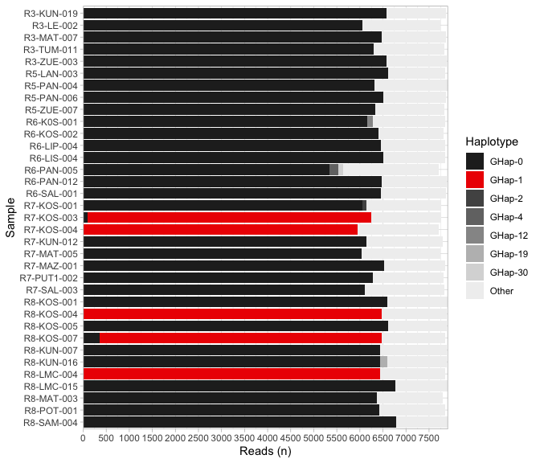

```r
plot.deepseq.haplotypes <- ggplot(bam2hap.all.cleaned, aes(Sample,count, fill=GHap)) +
  geom_bar(stat="identity", position="stack") +
  labs(x="Sample",y="Reads (n)", fill="Haplotype") +
  theme_light() +
  scale_y_continuous(breaks=seq(0,8500,500), expand=c(0,0)) +
  scale_fill_manual(breaks=c("GHap-0", "GHap-1", "GHap-2", "GHap-4", "GHap-12", "GHap-19", "GHap-30","Other"),values=c("#252525","red2","#525252","#737373","#969696","#bdbdbd","#d9d9d9","#f0f0f0")) +
  coord_flip() +
  NULL

plot.deepseq.haplotypes
```

Look at putative heterozygotes

```r
bam2hap.all[bam2hap.all.cleaned$Sample %in% c("R8-KOS-007","R7-KOS-003"),]
```

|  | read | count | Sample | WindowStart | WindowEnd | FilteredSampleDepth | Seq_haplotype | haplotype | Gcount | window | GHap | hapnames |
| --- | --- | --- | --- | --- | --- | --- | --- | --- | --- | --- | --- | --- |
| 18 | TAAAGAAGCCGGTTACCCATAGTTAGACGGAAAGACCCCGTGAACCTTCACCGTAGCTTACTATTGGAACTTGG | 90 | R7-KOS-003.bam | 6359 | 6432 | 7757 | SHap-1 | TAAAGAAGCCGGTTACCCATAGTTAGACGGAAAGACCCCGTGAACCTTCACCGTAGCTTACTATTGGAACTTGG | 191835 | 6359 | GHap-0 | R7-KOS-003.bam_Window-6359-6432_SHap-1_GHap-0_Count-90 |
| 26 | TAAAGAAGCCGGTTACCCATAGTTAGACGGAAAGACCCCGTGAACCTTCACCGTAGCTTACTATTGGAACTTGG | 356 | R8-KOS-007.bam | 6359 | 6432 | 7854 | SHap-1 | TAAAGAAGCCGGTTACCCATAGTTAGACGGAAAGACCCCGTGAACCTTCACCGTAGCTTACTATTGGAACTTGG | 191835 | 6359 | GHap-0 | R8-KOS-007.bam_Window-6359-6432_SHap-1_GHap-0_Count-356 |
| 33 | TAAAGAAGCCGGTTACCCATAGTTAGACGGAAAGACCCCGTGAACCCTCACCGTAGCTTACTATTGGAACTTGG | 124 | R6-K0S-001.bam | 6359 | 6432 | 7845 | SHap-1 | TAAAGAAGCCGGTTACCCATAGTTAGACGGAAAGACCCCGTGAACCCTCACCGTAGCTTACTATTGGAACTTGG | 644 | 6359 | GHap-12 | R6-K0S-001.bam_Window-6359-6432_SHap-1_GHap-12_Count-124 |
| 36 | GAAAGAAGCCGGTTACCCATAGTTAGACGGAAAGACCCCGTGAACCTTCACCGTAGCTTACTATTGGAACTTGG | 89 | R7-KOS-001.bam | 6359 | 6432 | 7758 | SHap-1 | GAAAGAAGCCGGTTACCCATAGTTAGACGGAAAGACCCCGTGAACCTTCACCGTAGCTTACTATTGGAACTTGG | 1648 | 6359 | GHap-2 | R7-KOS-001.bam_Window-6359-6432_SHap-1_GHap-2_Count-89 |
| NA | NA | NA | NA | NA | NA | NA | NA | NA | NA | NA | NA | NA |
| NA.1 | NA | NA | NA | NA | NA | NA | NA | NA | NA | NA | NA | NA |

```r
NA
NA
NA
```

# Look at phylogenetic context of index sample

The pretreatment index sample (R6-KOS-002) performed badly in sequencing (approximately 54% of genomic sites recovered), so couldn’t be included in the main phylogenies. Let’s build a sequence alignment including only the variable sites available for contextual analysis.

First generate a MSA using the standard mapping pipeline (which automatically applies ‘N’ to sites failing filters). Then use snps-sites to create a VCF from the alignment (positions will be relative to sequence alignement, so will include INDELs, therefore sites will not be relevant to reference).

```r
# read in VCF, plus site list
index.failure.full.aln <- data.frame(pegas::read.vcf(index.failure.full.aln.file),stringsAsFactors = F)
```

[output not shown]

```r
index.failure.full.sitelist <- read.table(index.failure.full.sitelist.file)

colnames(index.failure.full.aln) <- index.failure.full.sitelist$V1[c(2:nrow(index.failure.full.sitelist))]
```

Next, subset to sites that are included in “PNGL_R6-KO5002” (index sample).

```r
index.failure.exclude.missing <- index.failure.full.aln[,index.failure.full.aln["PNGL_R6-KO5002",]!="*"]

# Replace "*" with "N"
index.failure.exclude.missing2 <- data.frame(sapply(1:ncol(index.failure.exclude.missing), function(x) gsub("\\*","N",index.failure.exclude.missing[,x])), stringsAsFactors = F)
colnames(index.failure.exclude.missing2) <- colnames(index.failure.exclude.missing)
rownames(index.failure.exclude.missing2) <- rownames(index.failure.exclude.missing)

# How many variable sites?
ncol(index.failure.exclude.missing2)
```

```
[1] 625
```

```r
# what are the sites?
#colnames(index.failure.exclude.missing2)
```

Now export these sites as an alignment. Note that we cannot run Gubbins on this SNP-only alignment, but it can be examined for phylogenetic signal

```r
# Concatenate to make sequences
index.failure.msa.samples.seqs <- NULL
for (current.sample in rownames(index.failure.exclude.missing2)){
  index.failure.msa.samples.seqs <- c(index.failure.msa.samples.seqs,paste0(index.failure.exclude.missing2[current.sample,],collapse=""))
}

# make seqinr sequence alignment in R
index.failure.msa.samples.seqs.alignment <- seqinr::as.alignment(nb=length(rownames(index.failure.exclude.missing2)), nam=rownames(index.failure.exclude.missing2), seq=index.failure.msa.samples.seqs)

# Write out to fasta file using loop
#index.fasta.out.filename <- "/Users/mb29/Treponema/PNG_Lihir_Yaws_2018/Analysis/Mapping/map-1.6-to-Samoa-masked_Lihir-CATreads_+_Global_2019-09-20/TPE_74pc-genome-cov+_index-sample54pc.index-seq-variable-sites.fas"

index.fasta.out.filename <- "TPE_74pc-genome-cov+_index-sample54pc.index-seq-variable-sites.fas"

for (current.sample in c(1:length(rownames(index.failure.exclude.missing2)))){
  seqinr::write.fasta(names = index.failure.msa.samples.seqs.alignment$nam[current.sample], sequences = index.failure.msa.samples.seqs.alignment$seq[current.sample], file.out = index.fasta.out.filename,open="a", as.string = T)
}
```

Use IQ-Tree to build SNP-only tree from alignment, then import and plot

```r
# import tree generated in IQ-Tree
index.failure.tree.phylo <- phytools::midpoint.root(read.tree(index.failure.tree.file))

# Fix tipnames
index.failure.tipnames <- data.frame(old.name=index.failure.tree.phylo$tip.label,stringsAsFactors = F)
index.failure.tipnames <- plyr::join(index.failure.tipnames,fix.tipnames, by="old.name")
index.failure.tipnames[1,"new.name"] <- "SamoaD_reference"
index.failure.tipnames[16,"new.name"] <- "TaïNP-2"

index.failure.tree.phylo$tip.label <- index.failure.tipnames$new.name


# Highlight resistant and index strains
resistant.strains.index <- c("R8-KOS-004" ,"R8-KOS-007" ,"R8-LMC-004")
index.strain <- "R6-KOS-002"
cls <- list(resistant=resistant.strains.index, index=index.strain)

# Create groups on tree
index.failure.tree.phylo <- groupOTU(index.failure.tree.phylo, cls)


# Do some processing on ML tree (e.g. nodes for bootstrapping)
index.failure.tree.phylo.data <- data.frame(ggtree(index.failure.tree.phylo)$data,stringsAsFactors=F)
index.failure.tree.phylo.data.nodes <- index.failure.tree.phylo.data[!index.failure.tree.phylo.data$isTip,]
index.failure.tree.phylo.data.nodes$label <- as.numeric(index.failure.tree.phylo.data.nodes$label)
```

```
NAs introduced by coercion
```

```
Duplicated aesthetics after name standardisation: size
```

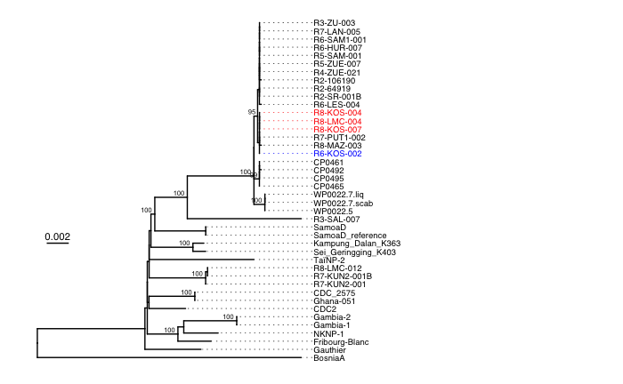

```r
index.failure.tree.phylo.data.nodes <- index.failure.tree.phylo.data.nodes[index.failure.tree.phylo.data.nodes$label >= 95,]

# now build tree
index.failure.tree.phylo.data.ggtree <- ggtree(index.failure.tree.phylo, ladderize = T) +
  geom_text(data=index.failure.tree.phylo.data.nodes, aes(label=label), size=2, hjust=1.25, vjust=-0.4)

# plot tree
index.failure.tree.phylo.data.ggtree +
  geom_tiplab(aes(color=group),size=2.5,align=T, offset=0.001, linesize=0.25) +
  xlim_tree(0.05) +
  scale_color_manual(values=c("black","blue","red")) +
  geom_treescale(fontsize=3,y=15,x=0.00085)
```